# R tutorial for analysing AMR phenotypic data

Sara Burgess

2025-03-27

## Day 1

**Setting up an R project**

It is good practice to set up your analysis as an R project. This enables reproducible code, you can share your zipped project file with others and it can be linked with github.

Set up an R project.

[figure not shown]

Once your project has been setup you can open it during a new R studio session by selecting:

File > Open Project

Browse to project directory

Open .Rproj file $\\ \\$

**Terminology**

*Function*: It takes arguments as the input, processes them using a set of operations, and returns an output.

To find out the arguments of a function use ? or help

```r
?read.csv
help(read.csv)
```

*Argument*: The expressions that are passed into a function.

*Assignment operator*: <- Assigns the values/data frame, vector, list etc… on the right to the object on the left.

*Object*: All items that are stored in R are considered objects. They can be a number, vector, dataframe, function etc… These are assigned to an object using <-.

*Data frame*: Data displayed in a 2-dimensional like table.

*Tibble*: A modern version of a data frame used by the tidyverse package. See https://tibble.tidyverse.org/.

*Vector*: 1-dimensional data array.

```r
# Numeric vector
num_vec <- c(1, 2, 3, 4, 5)

# Character vector
char_vec <- c("carrot", "cabbage", "onion")

# Logical vector
log_vec <- c(TRUE, FALSE, TRUE)
```

*Pipe Operator*: %>% chains together several operations so that the result of the previous line feeds into the subsequent line.

*Package*: Collection of functions, code, data etc… to perform particular tasks.

*Tidyverse*: A collection of easy to use R packages designed for data scientists to carry out data analyses such as tidying, manipulating and plotting data. $\\ \\$

**Installing and loading packages**

Install the R packages AMR, tidyverse, cleaner and readxl.

New packages can be installed by selecting:

Tools > Install Packages

Alternatively use the R code below

```r
install.packages("AMR")
install.packages("tidyverse")
install.packages("readxl")
install.packages("cleaner")
```

Load the packages.

```r
library(AMR)
library(tidyverse)
library(readxl)
library(cleaner)
## Warning: package 'cleaner' was built under R version 4.4.3
```

Note: Packages will need to loaded at the beginning of each R session.$\\ \\$

**Reading in data**

Read in a csv file using base R

```r
campy <- read.csv("data/Campylobacter_117.csv", header = TRUE)
```

```
## Error in make.names(col.names, unique = TRUE): invalid multibyte string 3
```

Why do we get this error?

Read in a modified csv file that does not contain these characters.

```r
campy <- read.csv("data/Campylobacter_117v2.csv", header = TRUE)
```

Read in the csv file using the readr package from tidyverse.

```r
campy <- read_csv("data/Campylobacter_117v2.csv")
```

```
## ──────────────────────────────────────────────────────── Delimiter: "," chr
## (9): Sample ID, Organism Isolated, Sensitive, Intermediate, Resistant (S... dbl
## (8): LAB CODE, Gentamicin (10ug), Tetracyclin (30ug), Ampicillin (10ug),...
```

The advantages of using read_csv are: you do not need to specify that the first line of data are column names, it is faster and it provides more information on the file you are reading.

Read in an excel sheet using the readxl package.

```r
ecoli <- read_excel("data/Bh_AMR_Surveillance data.xlsx", sheet = "E.coli")
```

**Checking and tidying data**

Some recommendations for “tidy data” include:

- Keep names simple
- Use an underscore _ instead of a space or preferably one word
- Use abbreviated words instead of a symbol. e.g. perc instead of %
- Be consistent between tables e.g. id versus i.d versus ID
- Each variable results in one column
- Each observation results in one row

The function str() is probably the most important function in R for checking the structure of your data. This gives you information on the number of rows and columns, the names of your columns, the class of each column.

```r
str(ecoli)
```

```
## tibble [126 × 32] (S3: tbl_df/tbl/data.frame)
##  $ Name of meat shop                   : chr [1:126] "XXX MS" "Wangyal MS" "TP MS" "Samjana MS" ...
##  $ Stratification                      : chr [1:126] "STII-05" "STII-07" "STII-02" "STII-03" ...
##  $ Date of sample collection           : chr [1:126] "23-08-2021" "23-08-2021" "23-08-2021" "23-08-2021" ...
##  $ Sample type                         : chr [1:126] "Broiler" "Broiler" "Broiler" "Broiler" ...
##  $ Point of sample collection          : chr [1:126] "Display table" "Display table" "Display table" "Fridge" ...
##  $ Sample weight (Kg)                  : num [1:126] 2.5 2.25 2.1 2.19 1.5 ...
##  $ Dzongkhag (sample source)           : chr [1:126] "Samtse" "Chukha" "Chukha" "Samtse" ...
##  $ Farm category                       : chr [1:126] "Semi-commercial" "Commercial" "Commercial" "Semi-commercial" ...
##  $ Slaughter                           : chr [1:126] "Farm premises" "Meat processing plant" "Meat processing plant" "Farm premises" ...
##  $ Mode of Transportation              : chr [1:126] "Closed meat van" "Closed meat van" "Closed meat van" "Closed meat van" ...
##  $ Transport medium                    : chr [1:126] "Thermo cool box" "Individual plastic wrap" "Individual plastic wrap" "Puff box" ...
##  $ Transported along with other meat?  : chr [1:126] "No" "No" "No" "No" ...
##  $ Gentamicin (10µg)                   : num [1:126] 19 18 18 18 18 17 18 18 18 20 ...
##  $ SIR...14                            : logi [1:126] NA NA NA NA NA NA ...
```

[output cut: 18 more lines]

Use the functions head(), tail(), glimpse(), summary() and table() to check your data. How are these functions different?

```r
head(ecoli)
```

```
## # A tibble: 6 × 32
##   `Name of meat shop` Stratification `Date of sample collection` `Sample type`
##   <chr>               <chr>          <chr>                       <chr>
## 1 XXX MS              STII-05        23-08-2021                  Broiler
## 2 Wangyal MS          STII-07        23-08-2021                  Broiler
## 3 TP MS               STII-02        23-08-2021                  Broiler
## 4 Samjana MS          STII-03        23-08-2021                  Broiler
## 5 BB MS               STI-04         24-08-2021                  Broiler
## 6 Saspra MS           STI-01         44356                       Broiler
## # ℹ 28 more variables: `Point of sample collection` <chr>,
## #   `Sample weight (Kg)` <dbl>, `Dzongkhag (sample source)` <chr>,
## #   `Farm category` <chr>, Slaughter <chr>, `Mode of Transportation` <chr>,
## #   `Transport medium` <chr>, `Transported along with other meat?` <chr>,
## #   `Gentamicin (10µg)` <dbl>, SIR...14 <lgl>, `Chloramphenicol (30µg)` <dbl>,
## #   SIR...16 <lgl>, `Meropenem (10µg)` <dbl>, SIR...18 <lgl>,
## #   `Ceftriaxone(30µg)` <dbl>, SIR...20 <lgl>, `Ciprofloxacin (5µg)` <dbl>, …
```

```r
tail(ecoli)
```

```
## # A tibble: 6 × 32
##   `Name of meat shop` Stratification `Date of sample collection` `Sample type`
##   <chr>               <chr>          <chr>                       <chr>
## 1 Good Meal MS        STIII-03       16/12/2022                  Broiler
## 2 BK MS               STIII-07       16/12/2022                  Broiler
## 3 Samjana MS          STII-03        16/12/2022                  Broiler
## 4 Himalayan MS        STI-02         16/12/2022                  Broiler
## 5 Subba MS            STII-14        16/12/2022                  Broiler
## 6 Tila MS             STII-23        16/12/2022                  Broiler
## # ℹ 28 more variables: `Point of sample collection` <chr>,
## #   `Sample weight (Kg)` <dbl>, `Dzongkhag (sample source)` <chr>,
## #   `Farm category` <chr>, Slaughter <chr>, `Mode of Transportation` <chr>,
## #   `Transport medium` <chr>, `Transported along with other meat?` <chr>,
## #   `Gentamicin (10µg)` <dbl>, SIR...14 <lgl>, `Chloramphenicol (30µg)` <dbl>,
## #   SIR...16 <lgl>, `Meropenem (10µg)` <dbl>, SIR...18 <lgl>,
## #   `Ceftriaxone(30µg)` <dbl>, SIR...20 <lgl>, `Ciprofloxacin (5µg)` <dbl>, …
```

```r
glimpse(ecoli)
```

```
## Rows: 126
## Columns: 32
## $ `Name of meat shop`                    <chr> "XXX MS", "Wangyal MS", "TP MS"…
## $ Stratification                         <chr> "STII-05", "STII-07", "STII-02"…
## $ `Date of sample collection`            <chr> "23-08-2021", "23-08-2021", "23…
## $ `Sample type`                          <chr> "Broiler", "Broiler", "Broiler"…
## $ `Point of sample collection`           <chr> "Display table", "Display table…
## $ `Sample weight (Kg)`                   <dbl> 2.500, 2.250, 2.100, 2.190, 1.4…
## $ `Dzongkhag (sample source)`            <chr> "Samtse", "Chukha", "Chukha", "…
## $ `Farm category`                        <chr> "Semi-commercial", "Commercial"…
## $ Slaughter                              <chr> "Farm premises", "Meat processi…
## $ `Mode of Transportation`               <chr> "Closed meat van", "Closed meat…
## $ `Transport medium`                     <chr> "Thermo cool box", "Individual …
## $ `Transported along with other meat?`   <chr> "No", "No", "No", "No", "No", "…
## $ `Gentamicin (10µg)`                    <dbl> 19, 18, 18, 18, 18, 17, 18, 18,…
```

[output cut: 19 more lines]

```r
summary(ecoli)
```

```
##  Name of meat shop  Stratification     Date of sample collection
##  Length:126         Length:126         Length:126
##  Class :character   Class :character   Class :character
##  Mode  :character   Mode  :character   Mode  :character
##
##
##
##  Sample type        Point of sample collection Sample weight (Kg)
##  Length:126         Length:126                 Min.   :0.790
##  Class :character   Class :character           1st Qu.:1.950
##  Mode  :character   Mode  :character           Median :2.100
##                                                Mean   :2.066
##                                                3rd Qu.:2.300
##                                                Max.   :2.900
##  Dzongkhag (sample source) Farm category       Slaughter
##  Length:126                Length:126         Length:126
##  Class :character          Class :character   Class :character
##  Mode  :character          Mode  :character   Mode  :character
##
##
##
##  Mode of Transportation Transport medium   Transported along with other meat?
##  Length:126             Length:126         Length:126
##  Class :character       Class :character   Class :character
##  Mode  :character       Mode  :character   Mode  :character
##
##
##
##  Gentamicin (10µg) SIR...14       Chloramphenicol (30µg) SIR...16
##  Min.   :13.00     Mode:logical   Min.   : 6.00          Mode:logical
##  1st Qu.:18.00     NA's:126       1st Qu.:20.00          NA's:126
##  Median :19.00                    Median :22.00
##  Mean   :18.66                    Mean   :21.71
##  3rd Qu.:19.00                    3rd Qu.:24.00
##  Max.   :23.00                    Max.   :33.00
##  Meropenem (10µg) SIR...18       Ceftriaxone(30µg) SIR...20
##  Min.   :17.00    Mode:logical   Min.   :10.00     Mode:logical
##  1st Qu.:29.00    NA's:126       1st Qu.:28.00     NA's:126
##  Median :30.00                   Median :29.00
##  Mean   :29.44                   Mean   :28.25
```

[output cut: 15 more lines]

```
##  Max.   :28.00                        Max.   :24.00
##  Tetracyclin (30µg) SIR...30       Trimethoprim–Sulfamethoxazole (25µg)
##  Min.   : 6.00      Mode:logical   Min.   : 6.00
##  1st Qu.: 8.00      NA's:126       1st Qu.:10.00
##  Median :16.00                     Median :16.00
##  Mean   :15.22                     Mean   :15.91
##  3rd Qu.:21.00                     3rd Qu.:21.75
##  Max.   :28.00                     Max.   :32.00
##  SIR...32
##  Mode:logical
##  NA's:126
##
##
##
##
```

```r
table(ecoli$'Name of meat shop', useNA = "ifany")
```

```
##
##            A.M MS       Abi Maya MS             AM MS         Babesa MS
##                 1                 1                 1                 3
##             BB MS          Bebak MS             BK MS             BM MS
##                 1                 1                 3                 1
##          Chang MS           Daga MS         Dagana MS             DB MS
##                 1                 1                 4                 3
##          Debsi MS        Dhimali MS             DJ MS         Dragon MS
##                 2                 2                 1                 4
##           Druk MS      Druk Star MS           Easy MS        Ghalley MS
##                 2                 1                 2                 2
##             GM MS      Good Meal MS      Himalayan MS             HN MS
##                 1                 3                 3                 1
##        Hontsho MS             IB MS             JN MS           Kaka MS
##                 1                 1                 3                 2
##         Kancha MS      Karmaling MS         Kerung MS            KRT MS
##                 2                 2                 2                 1
##          Lhams MS            M.G MS         Makcha MS           Maya MS
##                 2                 1                 1                 1
##             MK MS      Motithang MS             My MS         Olakha MS
##                 1                 2                 3                 1
##            P.R MS            P.T MS   Phendey-Ling MS           R.B. MS
##                 1                 2                 3                 1
##            Rai MS        Samjana MS         Saspra MS       Shingden MS
##                 1                 3                 1                 3
##         Sipsoo MS            SNR MS         Subash MS          Subba MS
##                 3                 4                 2                 3
##           Taba MS       Tek Maya MS          Tendu MS           Thai MS
##                 2                 2                 2                 2
## Three Brothers MS          Three MS           Tila MS           Town MS
##                 1                 2                 3                 2
##             TP MS        Tsirang MS          Ugyen MS        Wangyal MS
##                 1                 3                 2                 3
##            XXX MS
##                 3
```

$\\$

*Group activity*

What types of things could be tidied up in the “ecoli” dataset?

```r
colnames(ecoli)
```

```
##  [1] "Name of meat shop"
##  [2] "Stratification"
##  [3] "Date of sample collection"
##  [4] "Sample type"
##  [5] "Point of sample collection"
##  [6] "Sample weight (Kg)"
##  [7] "Dzongkhag (sample source)"
##  [8] "Farm category"
##  [9] "Slaughter"
## [10] "Mode of Transportation"
## [11] "Transport medium"
## [12] "Transported along with other meat?"
## [13] "Gentamicin (10µg)"
## [14] "SIR...14"
## [15] "Chloramphenicol (30µg)"
```

[output cut: 17 more lines]

$\\$

*Subsetting*

Select the columns of interest using The select() function from the dplyr package. The first argument is the dataframe and the subsequent arguments are the columns that are being selected.

```r
#Select by column number
select(ecoli, 11:13)
```

```
## # A tibble: 126 × 3
##    `Transport medium`      Transported along with other me…¹ `Gentamicin (10µg)`
##    <chr>                   <chr>                                           <dbl>
##  1 Thermo cool box         No                                                 19
##  2 Individual plastic wrap No                                                 18
##  3 Individual plastic wrap No                                                 18
##  4 Puff box                No                                                 18
##  5 With ice                No                                                 18
##  6 With ice                No                                                 17
##  7 Thermo cool box         No                                                 18
##  8 With ice                No                                                 18
##  9 With ice                No                                                 18
## 10 With ice                No                                                 20
## # ℹ 116 more rows
## # ℹ abbreviated name: ¹`Transported along with other meat?`
```

```r
#Select by column name
select(ecoli, Stratification, 'Dzongkhag (sample source)', 'Sample type')
```

```
## # A tibble: 126 × 3
##    Stratification `Dzongkhag (sample source)` `Sample type`
##    <chr>          <chr>                       <chr>
##  1 STII-05        Samtse                      Broiler
##  2 STII-07        Chukha                      Broiler
##  3 STII-02        Chukha                      Broiler
##  4 STII-03        Samtse                      Broiler
##  5 STI-04         Chukha                      Broiler
##  6 STI-01         Chukha                      Broiler
##  7 STII-15        Chukha                      Broiler
##  8 STII-23        Chukha                      Broiler
##  9 STI-15         Chukha                      Broiler
## 10 STI-35         Tsirang                     Broiler
## # ℹ 116 more rows
```

Select the columns of interest using base R.

```r
#Using base R to subset - all rows, columns 13:15
ecoli[,11:13]
```

```
## # A tibble: 126 × 3
##    `Transport medium`      Transported along with other me…¹ `Gentamicin (10µg)`
##    <chr>                   <chr>                                           <dbl>
##  1 Thermo cool box         No                                                 19
##  2 Individual plastic wrap No                                                 18
##  3 Individual plastic wrap No                                                 18
##  4 Puff box                No                                                 18
##  5 With ice                No                                                 18
##  6 With ice                No                                                 17
##  7 Thermo cool box         No                                                 18
##  8 With ice                No                                                 18
##  9 With ice                No                                                 18
## 10 With ice                No                                                 20
## # ℹ 116 more rows
## # ℹ abbreviated name: ¹`Transported along with other meat?`
```

For more on subsetting using base R see https://adv-r.hadley.nz/subsetting.html

Use the select function to remove the SIR columns (which contain no values) and assign it the object “ecoli_select”.

```r
#Remove columns
ecoli_select <- select(ecoli, !starts_with("SIR"))
str(ecoli_select)
```

```
## tibble [126 × 22] (S3: tbl_df/tbl/data.frame)
##  $ Name of meat shop                   : chr [1:126] "XXX MS" "Wangyal MS" "TP MS" "Samjana MS" ...
##  $ Stratification                      : chr [1:126] "STII-05" "STII-07" "STII-02" "STII-03" ...
##  $ Date of sample collection           : chr [1:126] "23-08-2021" "23-08-2021" "23-08-2021" "23-08-2021" ...
##  $ Sample type                         : chr [1:126] "Broiler" "Broiler" "Broiler" "Broiler" ...
##  $ Point of sample collection          : chr [1:126] "Display table" "Display table" "Display table" "Fridge" ...
##  $ Sample weight (Kg)                  : num [1:126] 2.5 2.25 2.1 2.19 1.5 ...
##  $ Dzongkhag (sample source)           : chr [1:126] "Samtse" "Chukha" "Chukha" "Samtse" ...
##  $ Farm category                       : chr [1:126] "Semi-commercial" "Commercial" "Commercial" "Semi-commercial" ...
##  $ Slaughter                           : chr [1:126] "Farm premises" "Meat processing plant" "Meat processing plant" "Farm premises" ...
##  $ Mode of Transportation              : chr [1:126] "Closed meat van" "Closed meat van" "Closed meat van" "Closed meat van" ...
##  $ Transport medium                    : chr [1:126] "Thermo cool box" "Individual plastic wrap" "Individual plastic wrap" "Puff box" ...
##  $ Transported along with other meat?  : chr [1:126] "No" "No" "No" "No" ...
##  $ Gentamicin (10µg)                   : num [1:126] 19 18 18 18 18 17 18 18 18 20 ...
##  $ Chloramphenicol (30µg)              : num [1:126] 22 24 23 24 25 24 22 21 21 23 ...
##  $ Meropenem (10µg)                    : num [1:126] 25 25 23 22 27 32 32 34 32 30 ...
##  $ Ceftriaxone(30µg)                   : num [1:126] 32 31 31 31 32 29 30 28 32 28 ...
##  $ Ciprofloxacin (5µg)                 : num [1:126] 18 26 28 16 27 26 31 31 31 29 ...
##  $ Cefepime (30µg)                     : num [1:126] 33 30 32 31 32 30 32 30 26 30 ...
##  $ Nalidixic acid (30µg)               : num [1:126] 24 19 21 6 28 19 18 17 14 6 ...
##  $ Ampicillin (10µg)                   : num [1:126] 20 6 23 22 6 6 6 17 6 6 ...
##  $ Tetracyclin (30µg)                  : num [1:126] 6 6 13 15 9 8 12 16 6 10 ...
##  $ Trimethoprim–Sulfamethoxazole (25µg): num [1:126] 27 6 6 14 18 14 14 21 6 14 ...
```

To only keep rows that match a certain condition the filter() function can be used.

```r
filter(ecoli, `Dzongkhag (sample source)` == "Thimphu")
```

```
## # A tibble: 7 × 32
##   `Name of meat shop` Stratification `Date of sample collection` `Sample type`
##   <chr>               <chr>          <chr>                       <chr>
## 1 Taba MS             STI-31         21/09/2021                  Broiler
## 2 Kerung MS           STII-10        21/09/2021                  Broiler
## 3 DB MS               STII-11        17/05/2022                  Spent layer
## 4 Rai MS              STI-16         17/05/2022                  Spent layer
## 5 HN MS               STI-18         17/05/2022                  Spent layer
## 6 Kerung MS           STII-10        29/09/2022                  Broiler
## 7 DB MS               STII-11        16/12/2022                  Broiler
## # ℹ 28 more variables: `Point of sample collection` <chr>,
## #   `Sample weight (Kg)` <dbl>, `Dzongkhag (sample source)` <chr>,
## #   `Farm category` <chr>, Slaughter <chr>, `Mode of Transportation` <chr>,
## #   `Transport medium` <chr>, `Transported along with other meat?` <chr>,
## #   `Gentamicin (10µg)` <dbl>, SIR...14 <lgl>, `Chloramphenicol (30µg)` <dbl>,
## #   SIR...16 <lgl>, `Meropenem (10µg)` <dbl>, SIR...18 <lgl>,
## #   `Ceftriaxone(30µg)` <dbl>, SIR...20 <lgl>, `Ciprofloxacin (5µg)` <dbl>, …
```

Multiple functions can also be chained together using %>%. In the example below the dataframe is piped into the select() function, which is used to select the columns of interest then the result from this is piped into the filter function, which is used to select those rows where the zone diameter for tetracycine is less than 15 mm.

```r
ecoli %>%
  select(`Dzongkhag (sample source)`, `Tetracyclin (30µg)`) %>%
  filter(`Tetracyclin (30µg)` < 15)
```

```
## # A tibble: 51 × 2
##    `Dzongkhag (sample source)` `Tetracyclin (30µg)`
##    <chr>                                      <dbl>
##  1 Samtse                                         6
##  2 Chukha                                         6
##  3 Chukha                                        13
##  4 Chukha                                         9
##  5 Chukha                                         8
##  6 Chukha                                        12
##  7 Chukha                                         6
##  8 Tsirang                                       10
##  9 Sarpang                                        6
## 10 Chukha                                        13
## # ℹ 41 more rows
```

```r
#select and filter using column index
ecoli %>%
  select(`Dzongkhag (sample source)`, 29) %>%
  filter(.[[2]] < 15)
```

```
## # A tibble: 51 × 2
##    `Dzongkhag (sample source)` `Tetracyclin (30µg)`
##    <chr>                                      <dbl>
##  1 Samtse                                         6
##  2 Chukha                                         6
##  3 Chukha                                        13
##  4 Chukha                                         9
##  5 Chukha                                         8
##  6 Chukha                                        12
##  7 Chukha                                         6
##  8 Tsirang                                       10
##  9 Sarpang                                        6
## 10 Chukha                                        13
## # ℹ 41 more rows
```

$\\$

**Renaming columns**

Rename the columns so that they are simple, informative, and do not contain any special characters.

```r
#Rename columns
colnames(ecoli_select) <- c("meatshop", "stratification", "date_collection", "sample_type", "sample_collection", "sample_weight_Kg", "sample_source", "farm_category", "slaughter", "transportation", "transport_medium", "transport_other_meat", "GEN", "CHL", "MEM", "CRO", "CIP",  "FEP", "NAL", "AMP", "TCY", "SXT")

#Alternatively use the set names function
setNames(ecoli, c("meat_shop", "stratification", "date_collection", "sample_type",
             "sample_collection", "sample_weight_Kg", "sample_source",
             "farm_category", "slaughter", "transportation", "transport_medium",
             "transport_with_other_meat", "GEN", "CHL",
             "MEM", "CRO", "CIP", "FEP", "NAL", "AMP", "TCY", "SXT"))
```

```
## # A tibble: 126 × 32
##    meat_shop   stratification date_collection sample_type sample_collection
##    <chr>       <chr>          <chr>           <chr>       <chr>
##  1 XXX MS      STII-05        23-08-2021      Broiler     Display table
##  2 Wangyal MS  STII-07        23-08-2021      Broiler     Display table
##  3 TP MS       STII-02        23-08-2021      Broiler     Display table
##  4 Samjana MS  STII-03        23-08-2021      Broiler     Fridge
##  5 BB MS       STI-04         24-08-2021      Broiler     Display table
##  6 Saspra MS   STI-01         44356           Broiler     Fridge
##  7 Dagana MS   STII-15        44356           Broiler     Display table
##  8 Tila MS     STII-23        44356           Broiler     Fridge
##  9 Dhimali MS  STI-15         44386           Broiler     Fridge
## 10 Abi Maya MS STI-35         21/09/2021      Broiler     Display table
## # ℹ 116 more rows
## # ℹ 27 more variables: sample_weight_Kg <dbl>, sample_source <chr>,
## #   farm_category <chr>, slaughter <chr>, transportation <chr>,
## #   transport_medium <chr>, transport_with_other_meat <chr>, GEN <dbl>,
## #   CHL <lgl>, MEM <dbl>, CRO <lgl>, CIP <dbl>, FEP <lgl>, NAL <dbl>,
## #   AMP <lgl>, TCY <dbl>, SXT <lgl>, `` <dbl>, `` <dbl>, `` <dbl>, `` <dbl>,
## #   `` <dbl>, `` <dbl>, `` <dbl>, `` <dbl>, `` <dbl>, `` <dbl>
```

In the above examples the antibiotic names have been changed to their abbreviated form. Check the abbreviation that is used by the AMR package for streptomycin.

```r
as.ab("streptomycin")
```

```
## Class 'ab'
## [1] STR1
```

To view all the antibiotics listed in the antibiotics data set from the AMR package:

```r
view(antibiotics)
```

Alternatively to rename specific columns use the rename() function.

```r
ecoli %>% rename(meatshop = `Name of meat shop`,
                 sample_collection = `Date of sample collection`)
```

```
## # A tibble: 126 × 32
##    meatshop    Stratification sample_collection `Sample type`
##    <chr>       <chr>          <chr>             <chr>
##  1 XXX MS      STII-05        23-08-2021        Broiler
##  2 Wangyal MS  STII-07        23-08-2021        Broiler
##  3 TP MS       STII-02        23-08-2021        Broiler
##  4 Samjana MS  STII-03        23-08-2021        Broiler
##  5 BB MS       STI-04         24-08-2021        Broiler
##  6 Saspra MS   STI-01         44356             Broiler
##  7 Dagana MS   STII-15        44356             Broiler
##  8 Tila MS     STII-23        44356             Broiler
##  9 Dhimali MS  STI-15         44386             Broiler
## 10 Abi Maya MS STI-35         21/09/2021        Broiler
## # ℹ 116 more rows
## # ℹ 28 more variables: `Point of sample collection` <chr>,
## #   `Sample weight (Kg)` <dbl>, `Dzongkhag (sample source)` <chr>,
## #   `Farm category` <chr>, Slaughter <chr>, `Mode of Transportation` <chr>,
## #   `Transport medium` <chr>, `Transported along with other meat?` <chr>,
## #   `Gentamicin (10µg)` <dbl>, SIR...14 <lgl>, `Chloramphenicol (30µg)` <dbl>,
## #   SIR...16 <lgl>, `Meropenem (10µg)` <dbl>, SIR...18 <lgl>, …
```

$\\$

*Formatting the date*

Some of the dates look like they may be in an excel serial date format. There are methods in R that you can use to format the dates into the same format.These will not be discussed here.

```r
head(ecoli_select$date_collection)
```

```
## [1] "23-08-2021" "23-08-2021" "23-08-2021" "23-08-2021" "24-08-2021"
## [6] "44356"
```

The lubridate package can be used for parsing dates into a date format. For example to convert a date into a month-day-year format. See https://lubridate.tidyverse.org/.

```r
mdy("4/1/17")
```

```
## [1] "2017-04-01"
```

This same function can be applied to a column in a dataframe.

Often dates will come through as class “character”. In the example above they are in the POSIXIt data type which is also a date/time data type. However, by using the lubridate function ymd() it is converted to the date data type, which means the lubridate package can then then be used for date analyses.

$\\$

*Adding and modifying columns*

The mutate() function can be used for creating new columns, deleting columns and modifying existing columns.

```r
#Adding a new column called species
ec_test <- ecoli_select %>% mutate(species = "Escherichia coli")
str(ec_test)
```

```
## tibble [126 × 23] (S3: tbl_df/tbl/data.frame)
##  $ meatshop            : chr [1:126] "XXX MS" "Wangyal MS" "TP MS" "Samjana MS" ...
##  $ stratification      : chr [1:126] "STII-05" "STII-07" "STII-02" "STII-03" ...
##  $ date_collection     : chr [1:126] "23-08-2021" "23-08-2021" "23-08-2021" "23-08-2021" ...
##  $ sample_type         : chr [1:126] "Broiler" "Broiler" "Broiler" "Broiler" ...
##  $ sample_collection   : chr [1:126] "Display table" "Display table" "Display table" "Fridge" ...
##  $ sample_weight_Kg    : num [1:126] 2.5 2.25 2.1 2.19 1.5 ...
##  $ sample_source       : chr [1:126] "Samtse" "Chukha" "Chukha" "Samtse" ...
##  $ farm_category       : chr [1:126] "Semi-commercial" "Commercial" "Commercial" "Semi-commercial" ...
##  $ slaughter           : chr [1:126] "Farm premises" "Meat processing plant" "Meat processing plant" "Farm premises" ...
##  $ transportation      : chr [1:126] "Closed meat van" "Closed meat van" "Closed meat van" "Closed meat van" ...
##  $ transport_medium    : chr [1:126] "Thermo cool box" "Individual plastic wrap" "Individual plastic wrap" "Puff box" ...
##  $ transport_other_meat: chr [1:126] "No" "No" "No" "No" ...
##  $ GEN                 : num [1:126] 19 18 18 18 18 17 18 18 18 20 ...
##  $ CHL                 : num [1:126] 22 24 23 24 25 24 22 21 21 23 ...
##  $ MEM                 : num [1:126] 25 25 23 22 27 32 32 34 32 30 ...
##  $ CRO                 : num [1:126] 32 31 31 31 32 29 30 28 32 28 ...
##  $ CIP                 : num [1:126] 18 26 28 16 27 26 31 31 31 29 ...
##  $ FEP                 : num [1:126] 33 30 32 31 32 30 32 30 26 30 ...
##  $ NAL                 : num [1:126] 24 19 21 6 28 19 18 17 14 6 ...
##  $ AMP                 : num [1:126] 20 6 23 22 6 6 6 17 6 6 ...
##  $ TCY                 : num [1:126] 6 6 13 15 9 8 12 16 6 10 ...
##  $ SXT                 : num [1:126] 27 6 6 14 18 14 14 21 6 14 ...
##  $ species             : chr [1:126] "Escherichia coli" "Escherichia coli" "Escherichia coli" "Escherichia coli" ...
```

```r
#Adding a new column using the tidyverse dataset starwars
starwars %>%
  select(name, height, mass) %>%
  mutate(
    mass2 = mass * 2)
```

```
## # A tibble: 87 × 4
##    name               height  mass mass2
##    <chr>               <int> <dbl> <dbl>
##  1 Luke Skywalker        172    77   154
##  2 C-3PO                 167    75   150
##  3 R2-D2                  96    32    64
##  4 Darth Vader           202   136   272
##  5 Leia Organa           150    49    98
##  6 Owen Lars             178   120   240
##  7 Beru Whitesun Lars    165    75   150
##  8 R5-D4                  97    32    64
##  9 Biggs Darklighter     183    84   168
## 10 Obi-Wan Kenobi        182    77   154
## # ℹ 77 more rows
```

```r
#Modify existing column height and remove mass column
starwars %>%
  select(name, height, mass, homeworld) %>%
  mutate(
    mass = NULL,
    height = height * 0.0328084 # convert to feet
  )
```

```
## # A tibble: 87 × 3
##    name               height homeworld
##    <chr>               <dbl> <chr>
##  1 Luke Skywalker       5.64 Tatooine
##  2 C-3PO                5.48 Tatooine
##  3 R2-D2                3.15 Naboo
##  4 Darth Vader          6.63 Tatooine
##  5 Leia Organa          4.92 Alderaan
##  6 Owen Lars            5.84 Tatooine
##  7 Beru Whitesun Lars   5.41 Tatooine
##  8 R5-D4                3.18 Tatooine
##  9 Biggs Darklighter    6.00 Tatooine
## 10 Obi-Wan Kenobi       5.97 Stewjon
## # ℹ 77 more rows
```

$\\$

*Exercise*

Open an R script and save it as workshop.R. Write an R script to read in and tidy the E. coli sheet from the version 2 excel file. It should contain the following:

1. Reads in the E.coli sheet and assigns it to ecoli.
2. Chains together the following operations and assigns it to ecoli_select.
- select all columns except those starting with “SIR”
- change the column names
- add a new column called species with “Escherichia coli” as the column value
3. Changes the date column to date format (using the lubridate library). Use ?lubridate to check what function should be used for parsing a date in the year-month-day format.

$\\$

*Manipulating categorical values*

Check whether the categorical variable values are consistent for the meat_shop categorical variable using the table function.

```r
table(ecoli_select$meat_shop, useNA = "ifany")
```

```
##
##            A.M MS       Abi Maya MS             AM MS         Babesa MS
##                 1                 1                 1                 3
##             BB MS          Bebak MS             BK MS             BM MS
##                 1                 1                 3                 1
##          Chang MS           Daga MS         Dagana MS             DB MS
##                 1                 1                 4                 3
##          Debsi MS        Dhimali MS             DJ MS         Dragon MS
##                 2                 2                 1                 4
##           Druk MS      Druk Star MS           Easy MS        Ghalley MS
##                 2                 1                 2                 2
##             GM MS      Good Meal MS      Himalayan MS             HN MS
##                 1                 3                 3                 1
##        Hontsho MS             IB MS             JN MS           Kaka MS
##                 1                 1                 3                 2
##         Kancha MS      Karmaling MS         Kerung MS            KRT MS
##                 2                 2                 2                 1
##          Lhams MS            M.G MS         Makcha MS           Maya MS
##                 2                 1                 1                 1
##             MK MS      Motithang MS             My MS         Olakha MS
##                 1                 2                 3                 1
##            P.R MS            P.T MS   Phendey-Ling MS           R.B. MS
##                 1                 2                 3                 1
##            Rai MS        Samjana MS         Saspra MS       Shingden MS
##                 1                 3                 1                 3
##         Sipsoo MS            SNR MS         Subash MS          Subba MS
##                 3                 4                 2                 3
##           Taba MS       Tek Maya MS          Tendu MS           Thai MS
##                 2                 2                 2                 2
## Three Brothers MS          Three MS           Tila MS           Town MS
##                 1                 2                 3                 2
##             TP MS        Tsirang MS          Ugyen MS        Wangyal MS
##                 1                 3                 2                 3
##            XXX MS
##                 3
```

```r
#Look for values with specific characteristics, e.g. check all fields use correct spelling of meat shop values
table(ecoli_select$meat_shop %in% c("AM MS", "DB MS", "GM MS"))
```

```
##
## FALSE  TRUE
##   121     5
```

Use the sort and unique functions to check the meat_shop categorical variable values.

```r
sort(unique(ecoli_select$meat_shop))
```

```
##  [1] "A.M MS"            "Abi Maya MS"       "AM MS"
##  [4] "Babesa MS"         "BB MS"             "Bebak MS"
##  [7] "BK MS"             "BM MS"             "Chang MS"
## [10] "Daga MS"           "Dagana MS"         "DB MS"
## [13] "Debsi MS"          "Dhimali MS"        "DJ MS"
## [16] "Dragon MS"         "Druk MS"           "Druk Star MS"
## [19] "Easy MS"           "Ghalley MS"        "GM MS"
## [22] "Good Meal MS"      "Himalayan MS"      "HN MS"
## [25] "Hontsho MS"        "IB MS"             "JN MS"
## [28] "Kaka MS"           "Kancha MS"         "Karmaling MS"
## [31] "Kerung MS"         "KRT MS"            "Lhams MS"
## [34] "M.G MS"            "Makcha MS"         "Maya MS"
## [37] "MK MS"             "Motithang MS"      "My MS"
## [40] "Olakha MS"         "P.R MS"            "P.T MS"
## [43] "Phendey-Ling MS"   "R.B. MS"           "Rai MS"
## [46] "Samjana MS"        "Saspra MS"         "Shingden MS"
## [49] "Sipsoo MS"         "SNR MS"            "Subash MS"
## [52] "Subba MS"          "Taba MS"           "Tek Maya MS"
## [55] "Tendu MS"          "Thai MS"           "Three Brothers MS"
## [58] "Three MS"          "Tila MS"           "Town MS"
## [61] "TP MS"             "Tsirang MS"        "Ugyen MS"
## [64] "Wangyal MS"        "XXX MS"
```

The base R function gsub() and the str_replace functions from the stringr packages can be used to replace strings.

Use gsub to remove “.”

```r
gsub("\\.", "", ecoli_select$meat_shop)
```

```
##   [1] "XXX MS"            "Wangyal MS"        "TP MS"
##   [4] "Samjana MS"        "BB MS"             "Saspra MS"
##   [7] "Dagana MS"         "Tila MS"           "Dhimali MS"
##  [10] "Abi Maya MS"       "Druk Star MS"      "Taba MS"
##  [13] "AM MS"             "DB MS"             "Kerung MS"
##  [16] "Sipsoo MS"         "Tsirang MS"        "IB MS"
##  [19] "Tek Maya MS"       "Motithang MS"      "Phendey-Ling MS"
##  [22] "Tila MS"           "Subba MS"          "Lhams MS"
##  [25] "Himalayan MS"      "Good Meal MS"      "Kaka MS"
##  [28] "Dragon MS"         "SNR MS"            "Tendu MS"
##  [31] "RB MS"             "Chang MS"          "Maya MS"
##  [34] "Olakha MS"         "Taba MS"           "Three MS"
##  [37] "Druk MS"           "XXX MS"            "Kancha MS"
##  [40] "Good Meal MS"      "PT MS"             "Dragon MS"
##  [43] "SNR MS"            "JN MS"             "Subba MS"
```

[output cut: 27 more lines]

Use str_replace to remove the “.” and replace “Bebak MS with BK MS” and assign to the object ecoli_select (add this to your workshop.R script).

```r
ecoli_select <- ecoli_select %>%
  mutate(meat_shop = str_replace_all(meat_shop, "\\.", ""),  # Remove all dots
         meat_shop = str_replace(meat_shop, "Bebak MS", "BK MS"))

sort(unique(ecoli_select$meat_shop))
```

```
##  [1] "Abi Maya MS"       "AM MS"             "Babesa MS"
##  [4] "BB MS"             "BK MS"             "BM MS"
##  [7] "Chang MS"          "Daga MS"           "Dagana MS"
## [10] "DB MS"             "Debsi MS"          "Dhimali MS"
## [13] "DJ MS"             "Dragon MS"         "Druk MS"
## [16] "Druk Star MS"      "Easy MS"           "Ghalley MS"
## [19] "GM MS"             "Good Meal MS"      "Himalayan MS"
## [22] "HN MS"             "Hontsho MS"        "IB MS"
## [25] "JN MS"             "Kaka MS"           "Kancha MS"
## [28] "Karmaling MS"      "Kerung MS"         "KRT MS"
## [31] "Lhams MS"          "Makcha MS"         "Maya MS"
## [34] "MG MS"             "MK MS"             "Motithang MS"
## [37] "My MS"             "Olakha MS"         "Phendey-Ling MS"
## [40] "PR MS"             "PT MS"             "Rai MS"
## [43] "RB MS"             "Samjana MS"        "Saspra MS"
## [46] "Shingden MS"       "Sipsoo MS"         "SNR MS"
## [49] "Subash MS"         "Subba MS"          "Taba MS"
## [52] "Tek Maya MS"       "Tendu MS"          "Thai MS"
## [55] "Three Brothers MS" "Three MS"          "Tila MS"
## [58] "Town MS"           "TP MS"             "Tsirang MS"
## [61] "Ugyen MS"          "Wangyal MS"        "XXX MS"
```

$\\$

*Exercise*

Check whether any of the other categorical values need to be changed and change where appropriate.Add these to your R script.

The farm_category column uses both a capital “C” and a lowercase “c” has been used for the word commercial.

```r
sort(unique(ecoli_select$farm_category))
```

```
## [1] "commercial"      "Commercial"      "Semi-commercial"
```

Here are some other ways that categorical values can be replaced.

```r
#Using the replace or str_replace functions.
mutate(ecoli_select, farm_category = replace(farm_category, farm_category == "commercial", "Commercial"))
```

```
## # A tibble: 126 × 23
##    meat_shop   stratification date_collection sample_type sample_collection
##    <chr>       <chr>          <date>          <chr>       <chr>
##  1 XXX MS      STII-05        2021-08-23      Broiler     Display table
##  2 Wangyal MS  STII-07        2021-08-23      Broiler     Display table
##  3 TP MS       STII-02        2021-08-23      Broiler     Display table
##  4 Samjana MS  STII-03        2021-08-23      Broiler     Fridge
##  5 BB MS       STI-04         2021-08-24      Broiler     Display table
##  6 Saspra MS   STI-01         2021-06-09      Broiler     Fridge
##  7 Dagana MS   STII-15        2021-06-09      Broiler     Display table
##  8 Tila MS     STII-23        2021-06-09      Broiler     Fridge
##  9 Dhimali MS  STI-15         2021-07-09      Broiler     Fridge
## 10 Abi Maya MS STI-35         2021-09-21      Broiler     Display table
## # ℹ 116 more rows
## # ℹ 18 more variables: sample_weight_Kg <dbl>, sample_source <chr>,
## #   farm_category <chr>, slaughter <chr>, transportation <chr>,
## #   transport_medium <chr>, transport_with_other_meat <chr>, GEN <dbl>,
## #   CHL <dbl>, MEM <dbl>, CRO <dbl>, CIP <dbl>, FEP <dbl>, NAL <dbl>,
## #   AMP <dbl>, TCY <dbl>, SXT <dbl>, species <chr>
```

```r
mutate(ecoli_select, farm_category = str_replace(farm_category, "commercial", "Commercial"))
```

```
## # A tibble: 126 × 23
##    meat_shop   stratification date_collection sample_type sample_collection
##    <chr>       <chr>          <date>          <chr>       <chr>
##  1 XXX MS      STII-05        2021-08-23      Broiler     Display table
##  2 Wangyal MS  STII-07        2021-08-23      Broiler     Display table
##  3 TP MS       STII-02        2021-08-23      Broiler     Display table
##  4 Samjana MS  STII-03        2021-08-23      Broiler     Fridge
##  5 BB MS       STI-04         2021-08-24      Broiler     Display table
##  6 Saspra MS   STI-01         2021-06-09      Broiler     Fridge
##  7 Dagana MS   STII-15        2021-06-09      Broiler     Display table
##  8 Tila MS     STII-23        2021-06-09      Broiler     Fridge
##  9 Dhimali MS  STI-15         2021-07-09      Broiler     Fridge
## 10 Abi Maya MS STI-35         2021-09-21      Broiler     Display table
## # ℹ 116 more rows
## # ℹ 18 more variables: sample_weight_Kg <dbl>, sample_source <chr>,
## #   farm_category <chr>, slaughter <chr>, transportation <chr>,
## #   transport_medium <chr>, transport_with_other_meat <chr>, GEN <dbl>,
## #   CHL <dbl>, MEM <dbl>, CRO <dbl>, CIP <dbl>, FEP <dbl>, NAL <dbl>,
## #   AMP <dbl>, TCY <dbl>, SXT <dbl>, species <chr>
```

```r
#recode() can be used for multiple replacements
ecoli_select %>%
  mutate(farm_category = recode(farm_category,
                                "Commercial" = "commercial",
                                "Semi-commercial" = "semi-commercial"))
```

```
## # A tibble: 126 × 23
##    meat_shop   stratification date_collection sample_type sample_collection
##    <chr>       <chr>          <date>          <chr>       <chr>
##  1 XXX MS      STII-05        2021-08-23      Broiler     Display table
##  2 Wangyal MS  STII-07        2021-08-23      Broiler     Display table
##  3 TP MS       STII-02        2021-08-23      Broiler     Display table
##  4 Samjana MS  STII-03        2021-08-23      Broiler     Fridge
##  5 BB MS       STI-04         2021-08-24      Broiler     Display table
##  6 Saspra MS   STI-01         2021-06-09      Broiler     Fridge
##  7 Dagana MS   STII-15        2021-06-09      Broiler     Display table
##  8 Tila MS     STII-23        2021-06-09      Broiler     Fridge
##  9 Dhimali MS  STI-15         2021-07-09      Broiler     Fridge
## 10 Abi Maya MS STI-35         2021-09-21      Broiler     Display table
## # ℹ 116 more rows
## # ℹ 18 more variables: sample_weight_Kg <dbl>, sample_source <chr>,
## #   farm_category <chr>, slaughter <chr>, transportation <chr>,
## #   transport_medium <chr>, transport_with_other_meat <chr>, GEN <dbl>,
## #   CHL <dbl>, MEM <dbl>, CRO <dbl>, CIP <dbl>, FEP <dbl>, NAL <dbl>,
## #   AMP <dbl>, TCY <dbl>, SXT <dbl>, species <chr>
```

```r
#Alternatively str_ functions can be used to change the case
mutate(ecoli_select, farm_category = str_to_lower(farm_category))
```

```
## # A tibble: 126 × 23
##    meat_shop   stratification date_collection sample_type sample_collection
##    <chr>       <chr>          <date>          <chr>       <chr>
##  1 XXX MS      STII-05        2021-08-23      Broiler     Display table
##  2 Wangyal MS  STII-07        2021-08-23      Broiler     Display table
##  3 TP MS       STII-02        2021-08-23      Broiler     Display table
##  4 Samjana MS  STII-03        2021-08-23      Broiler     Fridge
##  5 BB MS       STI-04         2021-08-24      Broiler     Display table
##  6 Saspra MS   STI-01         2021-06-09      Broiler     Fridge
##  7 Dagana MS   STII-15        2021-06-09      Broiler     Display table
##  8 Tila MS     STII-23        2021-06-09      Broiler     Fridge
##  9 Dhimali MS  STI-15         2021-07-09      Broiler     Fridge
## 10 Abi Maya MS STI-35         2021-09-21      Broiler     Display table
## # ℹ 116 more rows
## # ℹ 18 more variables: sample_weight_Kg <dbl>, sample_source <chr>,
## #   farm_category <chr>, slaughter <chr>, transportation <chr>,
## #   transport_medium <chr>, transport_with_other_meat <chr>, GEN <dbl>,
## #   CHL <dbl>, MEM <dbl>, CRO <dbl>, CIP <dbl>, FEP <dbl>, NAL <dbl>,
## #   AMP <dbl>, TCY <dbl>, SXT <dbl>, species <chr>
```

```r
ecoli_select <- mutate(ecoli_select, farm_category = str_to_title(farm_category))
unique(ecoli_select$farm_category)
```

```
## [1] "Semi-Commercial" "Commercial"
```

$\\ \\$

**Missing values**

Check whether there are any missing values. These are labelled as NA (meaning not available) in R.There are multiple ways to check for missing values

```r
#Display rows that aren't complete cases using base R to subset
ecoli_select[!complete.cases(ecoli_select),]
```

```
## # A tibble: 0 × 23
## # ℹ 23 variables: meat_shop <chr>, stratification <chr>,
## #   date_collection <date>, sample_type <chr>, sample_collection <chr>,
## #   sample_weight_Kg <dbl>, sample_source <chr>, farm_category <chr>,
## #   slaughter <chr>, transportation <chr>, transport_medium <chr>,
## #   transport_with_other_meat <chr>, GEN <dbl>, CHL <dbl>, MEM <dbl>,
## #   CRO <dbl>, CIP <dbl>, FEP <dbl>, NAL <dbl>, AMP <dbl>, TCY <dbl>,
## #   SXT <dbl>, species <chr>
```

```r
#Display rows that aren't complete cases using base R to subset
campy[!complete.cases(campy),]
```

```
## # A tibble: 3 × 17
##   `Sample ID` `LAB CODE` `Organism Isolated`   `Gentamicin (10ug)`
##   <chr>            <dbl> <chr>                               <dbl>
## 1 <NA>                 7 Camphylobacter                         20
## 2 <NA>                15 Camphylobacter                         20
## 3 <NA>               105 Camphylobacter jejuni                  10
## # ℹ 13 more variables: `Sensitive, Intermediate, Resistant (SIR)` <chr>,
## #   `Tetracyclin (30ug)` <dbl>, SIR...7 <chr>, `Ampicillin (10ug)` <dbl>,
## #   SIR...9 <chr>, `Nalidixic acid (30ug)` <dbl>, SIR...11 <chr>,
## #   `Ciprofloxacin (5ug)` <dbl>, SIR...13 <chr>, `Erythromycin (15ug)` <dbl>,
## #   SIR...15 <chr>, Streptomycin <dbl>, SIR...17 <chr>
```

```r
#Show rows where sample ID == NA
campy[is.na(campy$'Sample ID'), ]
```

```
## # A tibble: 3 × 17
##   `Sample ID` `LAB CODE` `Organism Isolated`   `Gentamicin (10ug)`
##   <chr>            <dbl> <chr>                               <dbl>
## 1 <NA>                 7 Camphylobacter                         20
## 2 <NA>                15 Camphylobacter                         20
## 3 <NA>               105 Camphylobacter jejuni                  10
## # ℹ 13 more variables: `Sensitive, Intermediate, Resistant (SIR)` <chr>,
## #   `Tetracyclin (30ug)` <dbl>, SIR...7 <chr>, `Ampicillin (10ug)` <dbl>,
## #   SIR...9 <chr>, `Nalidixic acid (30ug)` <dbl>, SIR...11 <chr>,
## #   `Ciprofloxacin (5ug)` <dbl>, SIR...13 <chr>, `Erythromycin (15ug)` <dbl>,
## #   SIR...15 <chr>, Streptomycin <dbl>, SIR...17 <chr>
```

```r
#If false no values are na
any(is.na(campy$'Sample ID'))
```

```
## [1] TRUE
```

```r
#Will check to see all values meet this conditon
all(ecoli_select$TCY >= 6)
```

```
## [1] TRUE
```

```r
# Displays entire df where TRUE == NA, FALSE there is no NA
head(is.na(campy))
```

```
##      Sample ID LAB CODE Organism Isolated Gentamicin (10ug)
## [1,]     FALSE    FALSE             FALSE             FALSE
## [2,]     FALSE    FALSE             FALSE             FALSE
## [3,]     FALSE    FALSE             FALSE             FALSE
## [4,]     FALSE    FALSE             FALSE             FALSE
## [5,]     FALSE    FALSE             FALSE             FALSE
## [6,]     FALSE    FALSE             FALSE             FALSE
##      Sensitive, Intermediate, Resistant (SIR) Tetracyclin (30ug) SIR...7
## [1,]                                    FALSE              FALSE   FALSE
## [2,]                                    FALSE              FALSE   FALSE
## [3,]                                    FALSE              FALSE   FALSE
## [4,]                                    FALSE              FALSE   FALSE
## [5,]                                    FALSE              FALSE   FALSE
## [6,]                                    FALSE              FALSE   FALSE
##      Ampicillin (10ug) SIR...9 Nalidixic acid (30ug) SIR...11
```

[output cut: 20 more lines]

$\\$

To remove all rows with missing values use the complete.cases function.

```r
#Check the dimensions before filtering
dim(campy)
```

```
## [1] 117  17
```

```r
#filter for complete cases
campy <- campy %>%
   filter(complete.cases(.))

#Check the dimensions after filtering
dim(campy)
```

```
## [1] 114  17
```

$\\$

To only remove rows where there are missing values in a specific column use the drop_na function

```r
drop_na(campy, 'Sample ID')
```

```
## # A tibble: 114 × 17
##    `Sample ID`                `LAB CODE` `Organism Isolated` `Gentamicin (10ug)`
##    <chr>                           <dbl> <chr>                             <dbl>
##  1 Thi/Gen/kar/chi-lay/2021-…          1 Campylobacter                        28
##  2 Thi/Gen/kar/Chi-Br/2021-02          2 Camphylobacter                       24
##  3 Thi/Gen/kar/chi-lay/21-04           3 Campylobacter                        26
##  4 Thi/Mew/lha/chi-lay/2021-…          4 Campylobacter                        28
##  5 Thi/Gen/Kar/chi-Bro/21-17           5 Camphylobacter                       26
##  6 Tsi/Gos/Zom/21/Chi-lay/01           6 Camphylobacter                       11
##  7 Tsi/Gos/Pel/21/Chi-lay/09           8 Camphylobacter spp                   30
##  8 Tsi/Gos/Pel/21/Chi-lay/11           9 Camphylobacter                       22
##  9 Tsi/Gos/Pel/21/Chi-Bro/12          10 Camphylobacter spp                   26
## 10 Tsi/Phu/Bur/21/Chi-Lay/17          11 Camphylobacter                       20
## # ℹ 104 more rows
## # ℹ 13 more variables: `Sensitive, Intermediate, Resistant (SIR)` <chr>,
## #   `Tetracyclin (30ug)` <dbl>, SIR...7 <chr>, `Ampicillin (10ug)` <dbl>,
## #   SIR...9 <chr>, `Nalidixic acid (30ug)` <dbl>, SIR...11 <chr>,
## #   `Ciprofloxacin (5ug)` <dbl>, SIR...13 <chr>, `Erythromycin (15ug)` <dbl>,
## #   SIR...15 <chr>, Streptomycin <dbl>, SIR...17 <chr>
```

$\\$

Alternatively missing values can be removed when when applying a function. For example when calculating the mean.

```r
mean(ecoli_select$TCY, na.rm = TRUE)
```

```
## [1] 15.22222
```

$\\ \\$

**Data distribution**

Check the distribution of disk diffusion values.

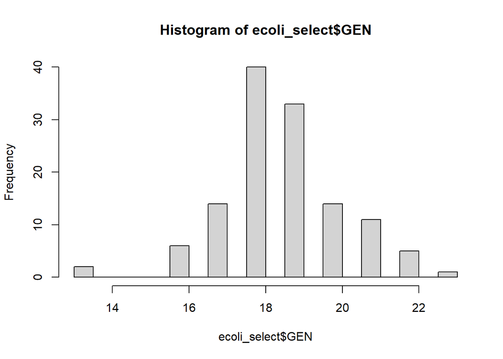

```r
#Checking what the phenotype looks like, that there were no strange values.
hist(ecoli_select$GEN, breaks = 20)
```

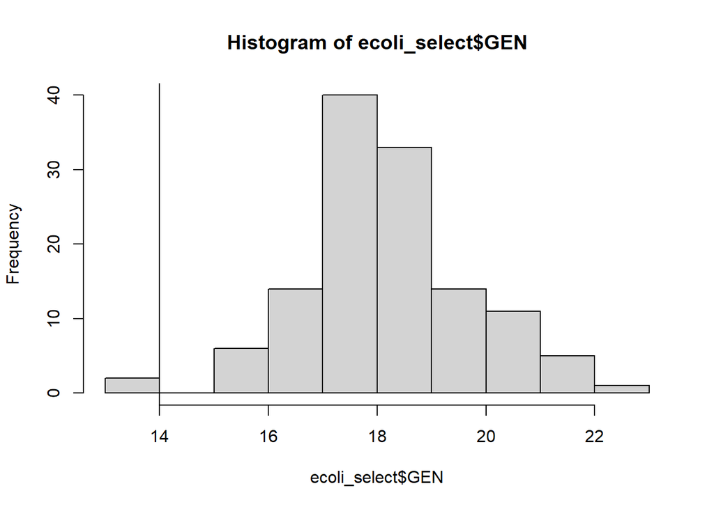

```r
hist(ecoli_select$GEN)
abline(v = 14)
```

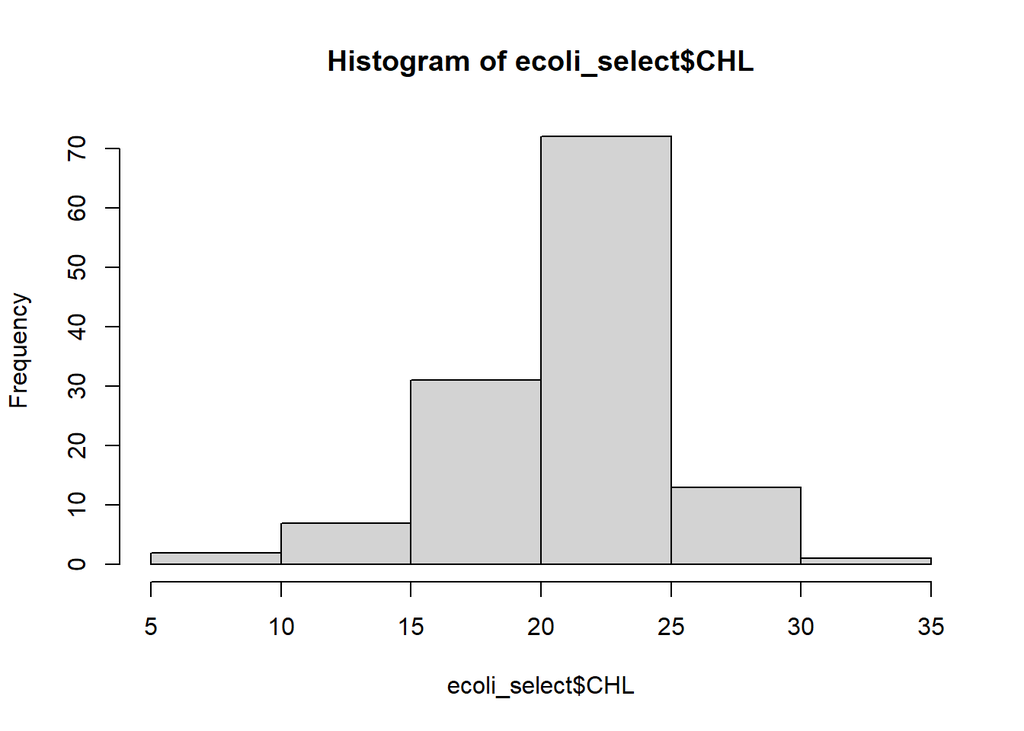

```r
hist(ecoli_select$CHL)
```

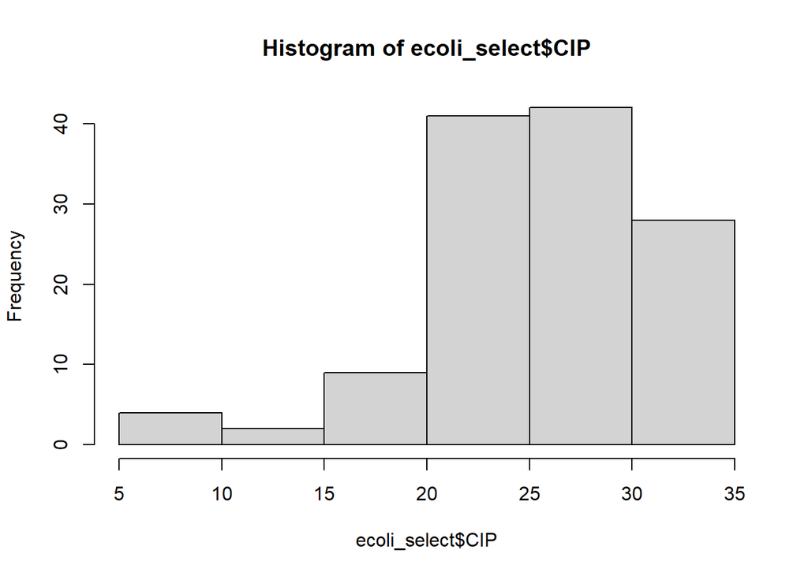

```r
hist(ecoli_select$CIP)
```

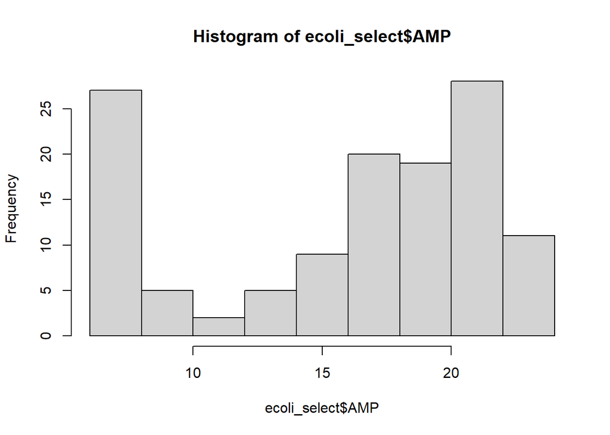

```r
hist(ecoli_select$AMP)
```

*Exercise*

Add code for the following to your R script.

- Read in the Enterococci and Salmonella excel sheets and assign them to “enterococci” and “salmonella”.
- Remove the SIR columns
- Change column names
- Add a column called species with the appropriate species name (e.g. Enterococcus sp. Salmonella sp.)
- Check the data for multiple types of categorical values, missing values, outliers etc…

Hint use the as.ab() function to find the abbreviations for tigecycline, vancomycin, quinupristin-dalfopristin, linzolid and ertapenem

Bind the ecoli, enteroccoci and salmonella data frames together.

```r
#Where columns don't match will get NA
df <- bind_rows(ecoli_select, salmonella_select, enterococci_select) %>%
  select(species, 1:29) #select species first then remainder of columns
str(df)
```

```
## tibble [393 × 29] (S3: tbl_df/tbl/data.frame)
##  $ species                  : chr [1:393] "Escherichia coli" "Escherichia coli" "Escherichia coli" "Escherichia coli" ...
##  $ meat_shop                : chr [1:393] "XXX MS" "Wangyal MS" "TP MS" "Samjana MS" ...
##  $ stratification           : chr [1:393] "STII-05" "STII-07" "STII-02" "STII-03" ...
##  $ date_collection          : Date[1:393], format: "2021-08-23" "2021-08-23" ...
##  $ sample_type              : chr [1:393] "Broiler" "Broiler" "Broiler" "Broiler" ...
##  $ sample_collection        : chr [1:393] "Display table" "Display table" "Display table" "Fridge" ...
##  $ sample_weight_Kg         : num [1:393] 2.5 2.25 2.1 2.19 1.5 ...
##  $ sample_source            : chr [1:393] "Samtse" "Chukha" "Chukha" "Samtse" ...
##  $ farm_category            : chr [1:393] "Semi-Commercial" "Commercial" "Commercial" "Semi-Commercial" ...
##  $ slaughter                : chr [1:393] "Farm premises" "Meat processing plant" "Meat processing plant" "Farm premises" ...
##  $ transportation           : chr [1:393] "Closed meat van" "Closed meat van" "Closed meat van" "Closed meat van" ...
##  $ transport_medium         : chr [1:393] "Thermo cool box" "Individual plastic wrap" "Individual plastic wrap" "Puff box" ...
##  $ transport_with_other_meat: chr [1:393] "No" "No" "No" "No" ...
##  $ GEN                      : num [1:393] 19 18 18 18 18 17 18 18 18 20 ...
##  $ CHL                      : num [1:393] 22 24 23 24 25 24 22 21 21 23 ...
##  $ MEM                      : num [1:393] 25 25 23 22 27 32 32 34 32 30 ...
##  $ CRO                      : num [1:393] 32 31 31 31 32 29 30 28 32 28 ...
##  $ CIP                      : num [1:393] 18 26 28 16 27 26 31 31 31 29 ...
##  $ FEP                      : num [1:393] 33 30 32 31 32 30 32 30 26 30 ...
##  $ NAL                      : num [1:393] 24 19 21 6 28 19 18 17 14 6 ...
##  $ AMP                      : num [1:393] 20 6 23 22 6 6 6 17 6 6 ...
##  $ TCY                      : num [1:393] 6 6 13 15 9 8 12 16 6 10 ...
##  $ SXT                      : num [1:393] 27 6 6 14 18 14 14 21 6 14 ...
##  $ ETP                      : num [1:393] NA NA NA NA NA NA NA NA NA NA ...
##  $ ERY                      : num [1:393] NA NA NA NA NA NA NA NA NA NA ...
##  $ TGC                      : num [1:393] NA NA NA NA NA NA NA NA NA NA ...
##  $ QDA                      : num [1:393] NA NA NA NA NA NA NA NA NA NA ...
##  $ VAN                      : num [1:393] NA NA NA NA NA NA NA NA NA NA ...
##  $ LNZ                      : num [1:393] NA NA NA NA NA NA NA NA NA NA ...
```

To bind columns from together from two data frames use one of the join functions inner_join(), left_join() (keeps all observations in x), right_join() (keeps all observations in y) or a full_join() see https://dplyr.tidyverse.org/reference/mutate-joins.html for more information. Here is one example.

```r
meta <- read_csv("data/metadata.csv")
df_join <- full_join(ecoli, meta, by = "Stratification")
str(df_join)
```

[output not shown]

## Day 2: Using the AMR R package

If the ecoli, enterococci and salmonella data sets are not still in your environment. Reload, tidy them and join them together by rerunning the script generated from day 1.

**Generating an antibiogram**

First the disk diffusion data is converted to “disk” data type and a new column is generated using the mutate_if() function for the SIR data. The is.disk() function is used to check whether the data is “disk” class and if true the as.sir() function is used to convert the disk diffusion values to “SIR” type. In the example below the disk diffusion values are converted to S, I or R based on the latest CLSI guidelines. You can change the AMR guideline using the guideline argument e.g. guideline == “CLSI 2023”.

```r
str(ecoli_select)
```

```
## tibble [126 × 23] (S3: tbl_df/tbl/data.frame)
##  $ meat_shop                : chr [1:126] "XXX MS" "Wangyal MS" "TP MS" "Samjana MS" ...
##  $ stratification           : chr [1:126] "STII-05" "STII-07" "STII-02" "STII-03" ...
##  $ date_collection          : Date[1:126], format: "2021-08-23" "2021-08-23" ...
##  $ sample_type              : chr [1:126] "Broiler" "Broiler" "Broiler" "Broiler" ...
##  $ sample_collection        : chr [1:126] "Display table" "Display table" "Display table" "Fridge" ...
##  $ sample_weight_Kg         : num [1:126] 2.5 2.25 2.1 2.19 1.5 ...
##  $ sample_source            : chr [1:126] "Samtse" "Chukha" "Chukha" "Samtse" ...
##  $ farm_category            : chr [1:126] "Semi-Commercial" "Commercial" "Commercial" "Semi-Commercial" ...
##  $ slaughter                : chr [1:126] "Farm premises" "Meat processing plant" "Meat processing plant" "Farm premises" ...
##  $ transportation           : chr [1:126] "Closed meat van" "Closed meat van" "Closed meat van" "Closed meat van" ...
##  $ transport_medium         : chr [1:126] "Thermo cool box" "Individual plastic wrap" "Individual plastic wrap" "Puff box" ...
##  $ transport_with_other_meat: chr [1:126] "No" "No" "No" "No" ...
##  $ GEN                      : num [1:126] 19 18 18 18 18 17 18 18 18 20 ...
##  $ CHL                      : num [1:126] 22 24 23 24 25 24 22 21 21 23 ...
##  $ MEM                      : num [1:126] 25 25 23 22 27 32 32 34 32 30 ...
##  $ CRO                      : num [1:126] 32 31 31 31 32 29 30 28 32 28 ...
##  $ CIP                      : num [1:126] 18 26 28 16 27 26 31 31 31 29 ...
##  $ FEP                      : num [1:126] 33 30 32 31 32 30 32 30 26 30 ...
##  $ NAL                      : num [1:126] 24 19 21 6 28 19 18 17 14 6 ...
##  $ AMP                      : num [1:126] 20 6 23 22 6 6 6 17 6 6 ...
##  $ TCY                      : num [1:126] 6 6 13 15 9 8 12 16 6 10 ...
##  $ SXT                      : num [1:126] 27 6 6 14 18 14 14 21 6 14 ...
##  $ species                  : chr [1:126] "Escherichia coli" "Escherichia coli" "Escherichia coli" "Escherichia coli" ...
```

```r
#Convert to "disk" data type
ecoli2 <- ecoli_select %>%
  mutate(across(GEN:SXT, as.disk))
str(ecoli2)
```

```
## tibble [126 × 23] (S3: tbl_df/tbl/data.frame)
##  $ meat_shop                : chr [1:126] "XXX MS" "Wangyal MS" "TP MS" "Samjana MS" ...
##  $ stratification           : chr [1:126] "STII-05" "STII-07" "STII-02" "STII-03" ...
##  $ date_collection          : Date[1:126], format: "2021-08-23" "2021-08-23" ...
##  $ sample_type              : chr [1:126] "Broiler" "Broiler" "Broiler" "Broiler" ...
##  $ sample_collection        : chr [1:126] "Display table" "Display table" "Display table" "Fridge" ...
##  $ sample_weight_Kg         : num [1:126] 2.5 2.25 2.1 2.19 1.5 ...
##  $ sample_source            : chr [1:126] "Samtse" "Chukha" "Chukha" "Samtse" ...
##  $ farm_category            : chr [1:126] "Semi-Commercial" "Commercial" "Commercial" "Semi-Commercial" ...
##  $ slaughter                : chr [1:126] "Farm premises" "Meat processing plant" "Meat processing plant" "Farm premises" ...
##  $ transportation           : chr [1:126] "Closed meat van" "Closed meat van" "Closed meat van" "Closed meat van" ...
##  $ transport_medium         : chr [1:126] "Thermo cool box" "Individual plastic wrap" "Individual plastic wrap" "Puff box" ...
##  $ transport_with_other_meat: chr [1:126] "No" "No" "No" "No" ...
##  $ GEN                      : 'disk' int [1:126] 19 18 18 18 18 17 18 18 18 20 ...
##  $ CHL                      : 'disk' int [1:126] 22 24 23 24 25 24 22 21 21 23 ...
##  $ MEM                      : 'disk' int [1:126] 25 25 23 22 27 32 32 34 32 30 ...
##  $ CRO                      : 'disk' int [1:126] 32 31 31 31 32 29 30 28 32 28 ...
##  $ CIP                      : 'disk' int [1:126] 18 26 28 16 27 26 31 31 31 29 ...
##  $ FEP                      : 'disk' int [1:126] 33 30 32 31 32 30 32 30 26 30 ...
##  $ NAL                      : 'disk' int [1:126] 24 19 21 6 28 19 18 17 14 6 ...
##  $ AMP                      : 'disk' int [1:126] 20 6 23 22 6 6 6 17 6 6 ...
##  $ TCY                      : 'disk' int [1:126] 6 6 13 15 9 8 12 16 6 10 ...
##  $ SXT                      : 'disk' int [1:126] 27 6 6 14 18 14 14 21 6 14 ...
##  $ species                  : chr [1:126] "Escherichia coli" "Escherichia coli" "Escherichia coli" "Escherichia coli" ...
```

```r
#To convert disk diffusion values to SIR
ecoli2 %>% mutate_if(is.disk, as.sir, guideline = "CLSI")
```

```
## ℹ Run sir_interpretation_history() afterwards to retrieve a logbook with
##   all the details of the breakpoint interpretations. Note that some
##   microorganisms might not have breakpoints for each antimicrobial drug in
##   CLSI 2023.
```

```
## Interpreting disk diffusion zones: 'GEN' (gentamicin) based on column
## 'species', CLSI 2023... OK
## Interpreting disk diffusion zones: 'CHL' (chloramphenicol) based on column
## 'species', CLSI 2023... OK
## Interpreting disk diffusion zones: 'MEM' (meropenem) based on column
## 'species', CLSI 2023... OK
## Interpreting disk diffusion zones: 'CRO' (ceftriaxone) based on column
## 'species', CLSI 2023... OK
## Interpreting disk diffusion zones: 'CIP' (ciprofloxacin) based on column
## 'species', CLSI 2023... OK
## Interpreting disk diffusion zones: 'FEP' (cefepime) based on column
## 'species', CLSI 2023... OK
## Interpreting disk diffusion zones: 'NAL' (nalidixic acid) based on column
## 'species', CLSI 2023... WARNING
## Interpreting disk diffusion zones: 'AMP' (ampicillin) based on column
## 'species', CLSI 2023... OK
## Interpreting disk diffusion zones: 'TCY' (tetracycline) based on column
## 'species', CLSI 2023... OK
## Interpreting disk diffusion zones: 'SXT' (trimethoprim/sulfamethoxazole)
## based on column 'species', CLSI 2023... OK
```

```
## # A tibble: 126 × 23
##    meat_shop   stratification date_collection sample_type sample_collection
##    <chr>       <chr>          <date>          <chr>       <chr>
##  1 XXX MS      STII-05        2021-08-23      Broiler     Display table
##  2 Wangyal MS  STII-07        2021-08-23      Broiler     Display table
##  3 TP MS       STII-02        2021-08-23      Broiler     Display table
##  4 Samjana MS  STII-03        2021-08-23      Broiler     Fridge
##  5 BB MS       STI-04         2021-08-24      Broiler     Display table
##  6 Saspra MS   STI-01         2021-06-09      Broiler     Fridge
##  7 Dagana MS   STII-15        2021-06-09      Broiler     Display table
##  8 Tila MS     STII-23        2021-06-09      Broiler     Fridge
##  9 Dhimali MS  STI-15         2021-07-09      Broiler     Fridge
## 10 Abi Maya MS STI-35         2021-09-21      Broiler     Display table
## # ℹ 116 more rows
## # ℹ 18 more variables: sample_weight_Kg <dbl>, sample_source <chr>,
## #   farm_category <chr>, slaughter <chr>, transportation <chr>,
## #   transport_medium <chr>, transport_with_other_meat <chr>, GEN <sir>,
## #   CHL <sir>, MEM <sir>, CRO <sir>, CIP <sir>, FEP <sir>, NAL <sir>,
## #   AMP <sir>, TCY <sir>, SXT <sir>, species <chr>
```

```r
#To copy disk diffusion values to new columns and convert to SIR
ecoli3 <- ecoli2 %>% mutate(across(GEN:SXT, ~ .x, .names = "{.col}_disk")) %>% #across the GEN:SXT columns copy values to new columns (~ defines an anonymous function, .x is placeholder for the column values )
  mutate(across(GEN:SXT, ~ as.sir(.x, guideline = "CLSI")))
```

```
## ℹ Run sir_interpretation_history() afterwards to retrieve a logbook with
##   all the details of the breakpoint interpretations. Note that some
##   microorganisms might not have breakpoints for each antimicrobial drug in
##   CLSI 2023.
##
## Interpreting disk diffusion zones: 'GEN' (gentamicin) based on column
## 'species', CLSI 2023... OK
## Interpreting disk diffusion zones: 'CHL' (chloramphenicol) based on column
## 'species', CLSI 2023... OK
## Interpreting disk diffusion zones: 'MEM' (meropenem) based on column
## 'species', CLSI 2023... OK
## Interpreting disk diffusion zones: 'CRO' (ceftriaxone) based on column
## 'species', CLSI 2023... OK
## Interpreting disk diffusion zones: 'CIP' (ciprofloxacin) based on column
## 'species', CLSI 2023... OK
## Interpreting disk diffusion zones: 'FEP' (cefepime) based on column
## 'species', CLSI 2023... OK
## Interpreting disk diffusion zones: 'NAL' (nalidixic acid) based on column
## 'species', CLSI 2023... WARNING
## Interpreting disk diffusion zones: 'AMP' (ampicillin) based on column
## 'species', CLSI 2023... OK
## Interpreting disk diffusion zones: 'TCY' (tetracycline) based on column
## 'species', CLSI 2023... OK
## Interpreting disk diffusion zones: 'SXT' (trimethoprim/sulfamethoxazole)
## based on column 'species', CLSI 2023... OK
```

```r
str(ecoli3)
```

```
## tibble [126 × 33] (S3: tbl_df/tbl/data.frame)
##  $ meat_shop                : chr [1:126] "XXX MS" "Wangyal MS" "TP MS" "Samjana MS" ...
##  $ stratification           : chr [1:126] "STII-05" "STII-07" "STII-02" "STII-03" ...
##  $ date_collection          : Date[1:126], format: "2021-08-23" "2021-08-23" ...
##  $ sample_type              : chr [1:126] "Broiler" "Broiler" "Broiler" "Broiler" ...
##  $ sample_collection        : chr [1:126] "Display table" "Display table" "Display table" "Fridge" ...
##  $ sample_weight_Kg         : num [1:126] 2.5 2.25 2.1 2.19 1.5 ...
##  $ sample_source            : chr [1:126] "Samtse" "Chukha" "Chukha" "Samtse" ...
##  $ farm_category            : chr [1:126] "Semi-Commercial" "Commercial" "Commercial" "Semi-Commercial" ...
##  $ slaughter                : chr [1:126] "Farm premises" "Meat processing plant" "Meat processing plant" "Farm premises" ...
##  $ transportation           : chr [1:126] "Closed meat van" "Closed meat van" "Closed meat van" "Closed meat van" ...
##  $ transport_medium         : chr [1:126] "Thermo cool box" "Individual plastic wrap" "Individual plastic wrap" "Puff box" ...
##  $ transport_with_other_meat: chr [1:126] "No" "No" "No" "No" ...
##  $ GEN                      : Ord.factor w/ 3 levels "S"<"I"<"R": 1 1 1 1 1 2 1 1 1 1 ...
##  $ CHL                      : Ord.factor w/ 3 levels "S"<"I"<"R": 1 1 1 1 1 1 1 1 1 1 ...
```

[output cut: 19 more lines]

Add the above code to your R script.

To define your own breakpoints:

```r
#generating an example dataframe
dat <- data.frame(
  patient_id = c("J3", "J3","J3","J3"),
  date = c("2018-11-21", "2018-04-03", "2018-09-19", "2018-12-10"),
  isolate = c(1,2,3,4),
  microorganism = c("Escherichia coli", "Escherichia coli", "Escherichia coli", "Escherichia coli"),
  CTX = c(27.2, 18.1, 34.0, 19.2),
  TCY = c(6.6, 7.2, 19.3, 17.2),
  STR = c(6.6, 12.5, 7.2, 17.2))
str(dat)
```

```
## 'data.frame':    4 obs. of  7 variables:
##  $ patient_id   : chr  "J3" "J3" "J3" "J3"
##  $ date         : chr  "2018-11-21" "2018-04-03" "2018-09-19" "2018-12-10"
##  $ isolate      : num  1 2 3 4
##  $ microorganism: chr  "Escherichia coli" "Escherichia coli" "Escherichia coli" "Escherichia coli"
##  $ CTX          : num  27.2 18.1 34 19.2
##  $ TCY          : num  6.6 7.2 19.3 17.2
##  $ STR          : num  6.6 12.5 7.2 17.2
```

```r
#To define breakpoints
dat2 <- dat %>%
  mutate(across(CTX:STR, as.disk)) %>%  # Convert values to "disk"
  mutate(STR = case_when( #modify the STR column using the following conditions
    STR >= 15 ~ "S",
    STR < 12  ~ "R",
    TRUE      ~ "I"
  )) %>%
  mutate(STR = factor(STR, levels = c("S", "I", "R"), ordered = TRUE)) %>%  # Convert STR to ordered factor
  mutate_if(is.disk, as.sir, guideline = "CLSI")  # Apply CLSI breakpoints
```

```
## ℹ Run sir_interpretation_history() afterwards to retrieve a logbook with
##   all the details of the breakpoint interpretations. Note that some
##   microorganisms might not have breakpoints for each antimicrobial drug in
##   CLSI 2023.
```

```
## Interpreting disk diffusion zones: 'CTX' (cefotaxime) based on column
## 'microorganism', CLSI 2023... OK
## Interpreting disk diffusion zones: 'TCY' (tetracycline) based on column
## 'microorganism', CLSI 2023... OK
```

```r
str(dat2)
```

```
## 'data.frame':    4 obs. of  7 variables:
##  $ patient_id   : chr  "J3" "J3" "J3" "J3"
##  $ date         : chr  "2018-11-21" "2018-04-03" "2018-09-19" "2018-12-10"
##  $ isolate      : num  1 2 3 4
##  $ microorganism: chr  "Escherichia coli" "Escherichia coli" "Escherichia coli" "Escherichia coli"
##  $ CTX          : Ord.factor w/ 3 levels "S"<"I"<"R": 1 3 1 3
##  $ TCY          : Ord.factor w/ 3 levels "S"<"I"<"R": 3 3 1 1
##  $ STR          : Ord.factor w/ 3 levels "S"<"I"<"R": 3 2 3 1
```

To specify that you want to use the veterinary breakpoints (rather than human).

```r
ecoli2 %>% mutate_if(is.disk, as.sir, guideline = "CLSI", breakpoint_type = "animal")
```

```
## ℹ Run sir_interpretation_history() afterwards to retrieve a logbook with
##   all the details of the breakpoint interpretations. Note that some
##   microorganisms might not have breakpoints for each antimicrobial drug in
##   CLSI 2023.
```

```
## Interpreting disk diffusion zones: 'GEN' (gentamicin) based on column
## 'species', CLSI 2023... OK
## Interpreting disk diffusion zones: 'CHL' (chloramphenicol) based on column
## 'species', CLSI 2023... WARNING
##   • No DISK breakpoints available for chloramphenicol (CHL).
## Interpreting disk diffusion zones: 'MEM' (meropenem) based on column
## 'species', CLSI 2023... WARNING
##   • No DISK breakpoints available for meropenem (MEM).
## Interpreting disk diffusion zones: 'CRO' (ceftriaxone) based on column
## 'species', CLSI 2023... WARNING
##   • No DISK breakpoints available for ceftriaxone (CRO).
## Interpreting disk diffusion zones: 'CIP' (ciprofloxacin) based on column
## 'species', CLSI 2023... WARNING
##   • No DISK breakpoints available for ciprofloxacin (CIP).
## Interpreting disk diffusion zones: 'FEP' (cefepime) based on column
## 'species', CLSI 2023... WARNING
##   • No DISK breakpoints available for cefepime (FEP).
## Interpreting disk diffusion zones: 'NAL' (nalidixic acid) based on column
## 'species', CLSI 2023... WARNING
##   • No DISK breakpoints available for nalidixic acid (NAL).
## Interpreting disk diffusion zones: 'AMP' (ampicillin) based on column
## 'species', CLSI 2023... OK
## Interpreting disk diffusion zones: 'TCY' (tetracycline) based on column
## 'species', CLSI 2023... OK
## Interpreting disk diffusion zones: 'SXT' (trimethoprim/sulfamethoxazole)
## based on column 'species', CLSI 2023... WARNING
##   • No DISK breakpoints available for trimethoprim/sulfamethoxazole (SXT).
```

```
## # A tibble: 126 × 23
##    meat_shop   stratification date_collection sample_type sample_collection
##    <chr>       <chr>          <date>          <chr>       <chr>
##  1 XXX MS      STII-05        2021-08-23      Broiler     Display table
##  2 Wangyal MS  STII-07        2021-08-23      Broiler     Display table
##  3 TP MS       STII-02        2021-08-23      Broiler     Display table
##  4 Samjana MS  STII-03        2021-08-23      Broiler     Fridge
##  5 BB MS       STI-04         2021-08-24      Broiler     Display table
##  6 Saspra MS   STI-01         2021-06-09      Broiler     Fridge
##  7 Dagana MS   STII-15        2021-06-09      Broiler     Display table
##  8 Tila MS     STII-23        2021-06-09      Broiler     Fridge
##  9 Dhimali MS  STI-15         2021-07-09      Broiler     Fridge
## 10 Abi Maya MS STI-35         2021-09-21      Broiler     Display table
## # ℹ 116 more rows
## # ℹ 18 more variables: sample_weight_Kg <dbl>, sample_source <chr>,
## #   farm_category <chr>, slaughter <chr>, transportation <chr>,
## #   transport_medium <chr>, transport_with_other_meat <chr>, GEN <sir>,
## #   CHL <sir>, MEM <sir>, CRO <sir>, CIP <sir>, FEP <sir>, NAL <sir>,
## #   AMP <sir>, TCY <sir>, SXT <sir>, species <chr>
```

Next generate an antibiogram:

```r
ant <- antibiogram(ecoli3,
            antibiotics = c("GEN", "CHL", "MEM", "CRO", "CIP", #select antibiotics to include in antibiogram
                           "FEP", "NAL", "AMP", "TCY", "SXT"),
            ab_transform = "name", #transform antibioitic abbreviations into full names
            digits = 1)  # Show one decimal place

ant
```

| Pathogen (N min-max) | Ampicillin | Cefepime | Ceftriaxone | Chloramphenicol | Ciprofloxacin | Gentamicin | Meropenem | Nalidixic acid | Tetracycline | Trimethoprim/sulfamethoxazole |
| --- | --- | --- | --- | --- | --- | --- | --- | --- | --- | --- |
| *E. coli* (126-126) | 71.4 | 99.2 | 92.9 | 96 | 82.5 | 98.4 | 95.2 | 62.7 | 66.7 | 69.8 |

The antibioram displays the percentage that are sensitive or intermediate.

Make a basic plot of the antibiograms using the autoplot() function.

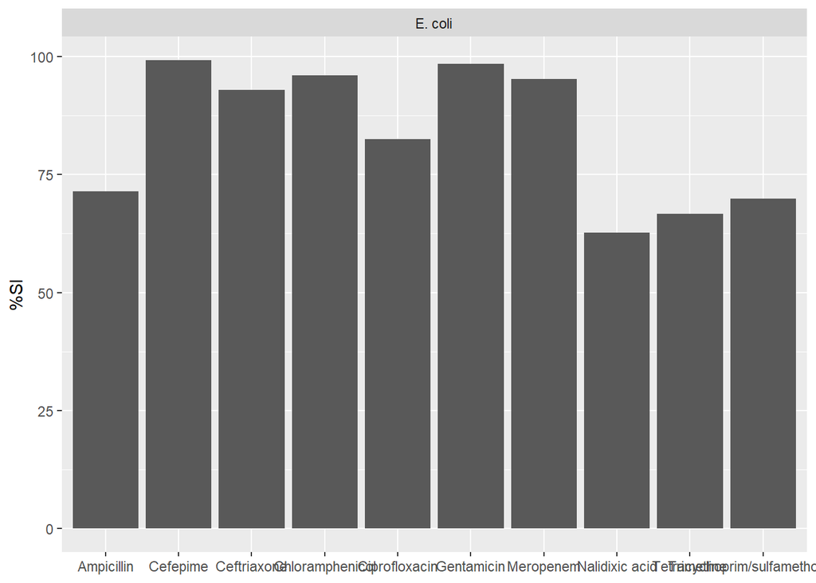

```r
autoplot(ant)
```

$\\$

*Exercise*

1. Generate SIR columns for the new df. First change the disk diffusion values to a disk data class and assign this to df2. Next, copy the disk diffusion values to new columns and covert the original disk diffusion columns to SIR and assign this to df3. Copy this code into your workshop.R script.
2. Generate the following antibiograms:
   - For the antibiotics CHL, AMP and TCY
   - For the species *E. coli*
   - For the groups fridge and display table (from the variable sample_collection) and antibiotics “CHL”, “AMP”, “TCY” and E. coli
3. Make some basic plots for each of the antibiograms

*Exercise 1*

```r
df2 <- df %>%
  mutate(across(GEN:LNZ, as.disk))


#To keep disk diffusion columns and add new columns with SIR
df3 <- df2 %>% mutate(across(GEN:LNZ, ~ .x, .names = "{.col}_disk")) %>%
  mutate(across(GEN:LNZ, ~ as.sir(.x, guideline = "CLSI")))
```

```
## ℹ Run sir_interpretation_history() afterwards to retrieve a logbook with
##   all the details of the breakpoint interpretations. Note that some
##   microorganisms might not have breakpoints for each antimicrobial drug in
##   CLSI 2023.
```

[output not shown]

```r
str(df3)
```

```
## tibble [393 × 45] (S3: tbl_df/tbl/data.frame)
##  $ species                  : chr [1:393] "Escherichia coli" "Escherichia coli" "Escherichia coli" "Escherichia coli" ...
##  $ meat_shop                : chr [1:393] "XXX MS" "Wangyal MS" "TP MS" "Samjana MS" ...
##  $ stratification           : chr [1:393] "STII-05" "STII-07" "STII-02" "STII-03" ...
##  $ date_collection          : Date[1:393], format: "2021-08-23" "2021-08-23" ...
##  $ sample_type              : chr [1:393] "Broiler" "Broiler" "Broiler" "Broiler" ...
##  $ sample_collection        : chr [1:393] "Display table" "Display table" "Display table" "Fridge" ...
##  $ sample_weight_Kg         : num [1:393] 2.5 2.25 2.1 2.19 1.5 ...
##  $ sample_source            : chr [1:393] "Samtse" "Chukha" "Chukha" "Samtse" ...
##  $ farm_category            : chr [1:393] "Semi-Commercial" "Commercial" "Commercial" "Semi-Commercial" ...
##  $ slaughter                : chr [1:393] "Farm premises" "Meat processing plant" "Meat processing plant" "Farm premises" ...
##  $ transportation           : chr [1:393] "Closed meat van" "Closed meat van" "Closed meat van" "Closed meat van" ...
##  $ transport_medium         : chr [1:393] "Thermo cool box" "Individual plastic wrap" "Individual plastic wrap" "Puff box" ...
##  $ transport_with_other_meat: chr [1:393] "No" "No" "No" "No" ...
##  $ GEN                      : Ord.factor w/ 3 levels "S"<"I"<"R": 1 1 1 1 1 2 1 1 1 1 ...
```

[output cut: 31 more lines]

*Exercise 2*

```r
ant1 <- antibiogram(df3,
            antibiotics = c("CHL", "AMP", "TCY"),
            ab_transform = "name",
            digits = 1)  # Show one decimal place

ant1
```

| Pathogen (N min-max) | Ampicillin | Chloramphenicol | Tetracycline |
| --- | --- | --- | --- |
| *E. coli* (126-126) | 71.4 | 96.0 | 66.7 |
| *Enterococcus* (239-239) | 94.1 | 98.3 | 77.0 |

```r
ant2 <- df3 %>%
  filter(species == "Escherichia coli") %>%
  antibiogram(ab_transform = "name",
            digits = 1)  # Show one decimal place

ant2
```

| Pathogen (N min-max) | Ampicillin | Cefepime | Ceftriaxone | Chloramphenicol | Ciprofloxacin | Gentamicin | Meropenem | Nalidixic acid | Tetracycline | Trimethoprim/sulfamethoxazole |
| --- | --- | --- | --- | --- | --- | --- | --- | --- | --- | --- |
| *E. coli* (0-126) | 71.4 | 99.2 | 92.9 | 96 | 82.5 | 98.4 | 95.2 | 62.7 | 66.7 | 69.8 |

```r
#Using the antibiogram function from the AMR package

ant3 <- df3 %>%
  filter(species == "Escherichia coli") %>%
  antibiogram(antibiotics = c("CHL", "AMP", "TCY"), syndromic_group = "sample_collection", ab_transform = "name",
            digits = 1,
             )

ant3
```

| Syndromic Group | Pathogen (N min-max) | Ampicillin | Chloramphenicol | Tetracycline |
| --- | --- | --- | --- | --- |
| Display table | *E. coli* (72-72) | 63.9 | 98.6 | 63.9 |
| Fridge | *E. coli* (54-54) | 81.5 | 92.6 | 70.4 |

*Exercise 3*

Make some basic plots of the antibiograms using the autoplot().

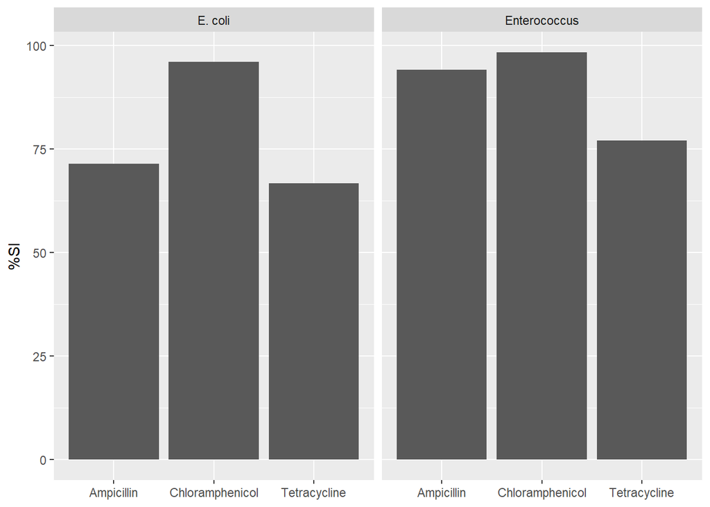

```r
autoplot(ant1)
```

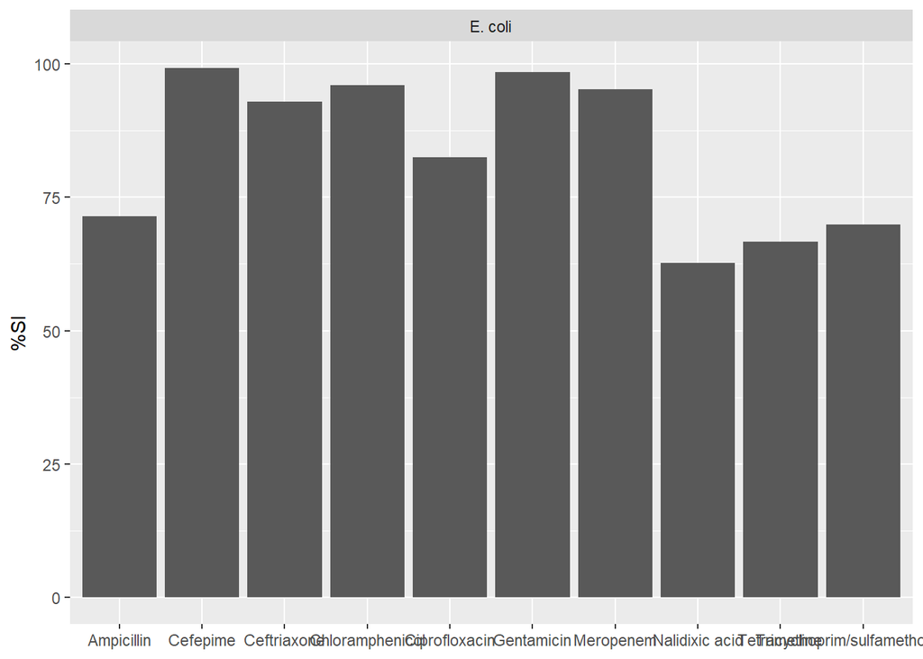

```r
autoplot(ant2)
```

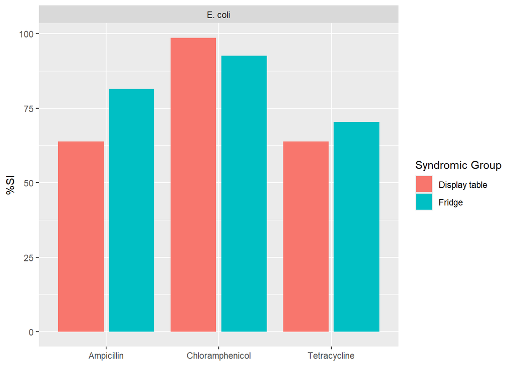

```r
autoplot(ant3)
```

Use dplyr and ggplot to generate antibiograms and a plot

```r
#Using  the AMR and dplyr packages

df3 %>%
  filter(species == "Escherichia coli") %>%
  select(sample_collection, CHL) %>%
  group_by(sample_collection) %>%
  count_df(translate = FALSE)
```

```
## # A tibble: 4 × 4
##   sample_collection antibiotic interpretation value
## * <chr>             <chr>      <ord>          <int>
## 1 Display table     CHL        SI                71
## 2 Display table     CHL        R                  1
## 3 Fridge            CHL        SI                50
## 4 Fridge            CHL        R                  4
```

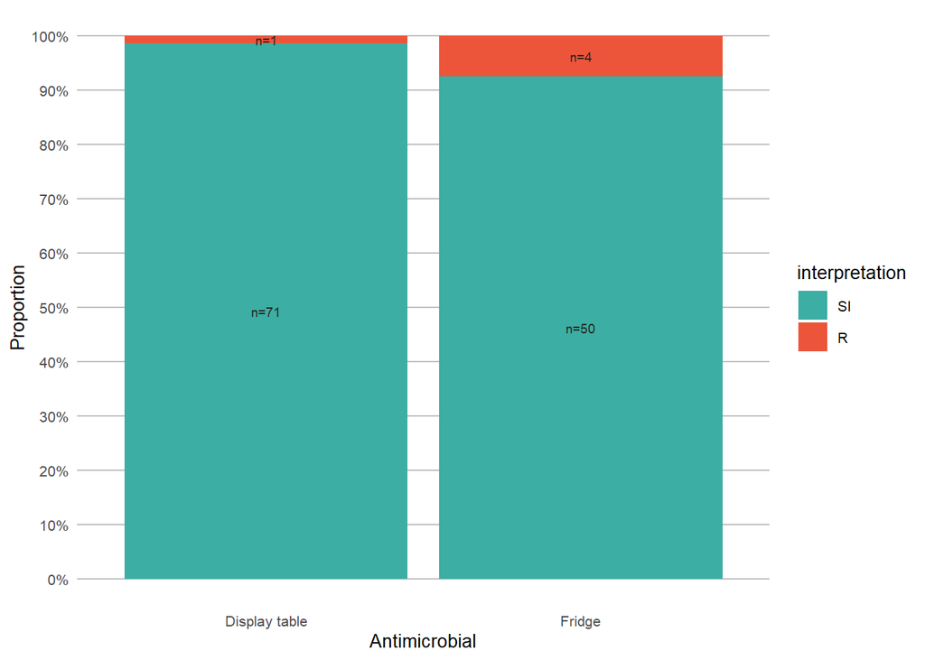

```r
#Plotting the antibiogram
df3 %>%
  filter(species == "Escherichia coli") %>%
  select(sample_collection, CHL) %>%
  group_by(sample_collection) %>%
  ggplot_sir(x = "sample_collection")
```

$\\ \\$

**Confidence intervals**

Use the AMR package function sir_confidence_interval() to calculate confidence intervals. This function uses the Clopper-Pearson method (using the binom.test())

```r
sir_confidence_interval(ecoli3$CHL)
```

```
## [1] 0.01300836 0.09017638
```

```r
df_summary <- ecoli3 %>%
  mutate(across(c(CHL, AMP, TCY), as.factor)) %>%  # Ensure that columns are factors
  summarise(
    CHL_percent_susceptible = mean(CHL == "S", na.rm = TRUE) * 100,
    AMP_percent_susceptible = mean(AMP == "S", na.rm = TRUE) * 100,
    TCY_percent_susceptible = mean(TCY == "S", na.rm = TRUE) * 100,

    # Calculate CI directly in the summarise function
    CHL_CI_lower = sir_confidence_interval(CHL)[1],
    CHL_CI_upper = sir_confidence_interval(CHL)[2],
    AMP_CI_lower = sir_confidence_interval(AMP)[1],
    AMP_CI_upper = sir_confidence_interval(AMP)[2],
    TCY_CI_lower = sir_confidence_interval(TCY)[1],
    TCY_CI_upper = sir_confidence_interval(TCY)[2]
  )

library(pander)
knitr::kable(df_summary)
```

| CHL_percent_susceptible | AMP_percent_susceptible | TCY_percent_susceptible | CHL_CI_lower | CHL_CI_upper | AMP_CI_lower | AMP_CI_upper | TCY_CI_lower | TCY_CI_upper |
| --- | --- | --- | --- | --- | --- | --- | --- | --- |
| 92.06349 | 61.90476 | 59.52381 | 0.0130084 | 0.0901764 | 0.2087997 | 0.3729886 | 0.2518972 | 0.4228075 |

## Day 3 - Using the AMR R Package

If the merged ecoli, enterococci and salmonella data set is not still in your environment. Reload the data sets, tidy them and join them together by rerunning the script generated from day 1 (to generate the data frame assigned to df3).

**First isolates**

Material for the following tutorial was taken from https://msberends.github.io/AMR/articles/AMR.html#first-isolates.

When there are multiple isolates from the same sample the function first_isolate() can be used to correct for duplicate isolates. There are four different methods that can be used for selecting the isolate(s) as described by [Hindler et al. (2007)](https://academic.oup.com/cid/article/44/6/867/364325). The default method is phenotype-based. The other three options are “episode-based”, “patient-based” and “isolate-based”.

Use the data set “example_isolates” that comes with the AMR package select the patient, ward, date, mo, AMX, AMC, CXM columns and filter for complete cases.

```r
our_data <- example_isolates %>%
  select(patient, ward, date, mo, AMX, AMC, CXM) %>%
  filter(complete.cases(.))

str(our_data)
```

```
## tibble [1,212 × 7] (S3: tbl_df/tbl/data.frame)
##  $ patient: chr [1:1212] "462729" "462729" "067927" "067927" ...
##  $ ward   : chr [1:1212] "Clinical" "Clinical" "ICU" "ICU" ...
##  $ date   : Date[1:1212], format: "2002-01-14" "2002-01-14" ...
##  $ mo     : 'mo' chr [1:1212] "B_STPHY_AURS" "B_STPHY_AURS" "B_SERRT_MRCS" "B_SERRT_MRCS" ...
##  $ AMX    : Ord.factor w/ 3 levels "S"<"I"<"R": 3 3 3 3 3 3 3 3 3 3 ...
##  $ AMC    : Ord.factor w/ 3 levels "S"<"I"<"R": 1 1 3 3 3 3 2 2 3 3 ...
##  $ CXM    : Ord.factor w/ 3 levels "S"<"I"<"R": 1 1 3 3 3 3 1 1 3 3 ...
```

Select first isolates based on the phenotype method.

```r
our_data %>%
  mutate(first = first_isolate()) #add a new column called first. Returns true if meets criteria of first isolate
```

```
## # A tibble: 1,212 × 8
##    patient ward     date       mo           AMX   AMC   CXM   first
##    <chr>   <chr>    <date>     <mo>         <sir> <sir> <sir> <lgl>
##  1 462729  Clinical 2002-01-14 B_STPHY_AURS R     S     S     TRUE
##  2 462729  Clinical 2002-01-14 B_STPHY_AURS R     S     S     FALSE
##  3 067927  ICU      2002-02-05 B_SERRT_MRCS R     R     R     TRUE
##  4 067927  ICU      2002-02-05 B_SERRT_MRCS R     R     R     FALSE
##  5 067927  ICU      2002-02-05 B_SERRT_MRCS R     R     R     FALSE
##  6 8FD3C4  Clinical 2002-02-24 B_STPHY_CONS R     R     R     TRUE
##  7 066895  Clinical 2002-02-27 B_KLBSL_PNMN R     I     S     TRUE
##  8 066895  Clinical 2002-02-27 B_KLBSL_PNMN R     I     S     FALSE
##  9 4FC193  Clinical 2002-03-08 B_ESCHR_COLI R     R     R     TRUE
## 10 4FC193  Clinical 2002-03-16 B_PSDMN_AERG R     R     R     TRUE
## # ℹ 1,202 more rows
```

```r
our_data %>%
  mutate(first = first_isolate(method = "phenotype-based"))
```

```
## # A tibble: 1,212 × 8
##    patient ward     date       mo           AMX   AMC   CXM   first
##    <chr>   <chr>    <date>     <mo>         <sir> <sir> <sir> <lgl>
##  1 462729  Clinical 2002-01-14 B_STPHY_AURS R     S     S     TRUE
##  2 462729  Clinical 2002-01-14 B_STPHY_AURS R     S     S     FALSE
##  3 067927  ICU      2002-02-05 B_SERRT_MRCS R     R     R     TRUE
##  4 067927  ICU      2002-02-05 B_SERRT_MRCS R     R     R     FALSE
##  5 067927  ICU      2002-02-05 B_SERRT_MRCS R     R     R     FALSE
##  6 8FD3C4  Clinical 2002-02-24 B_STPHY_CONS R     R     R     TRUE
##  7 066895  Clinical 2002-02-27 B_KLBSL_PNMN R     I     S     TRUE
##  8 066895  Clinical 2002-02-27 B_KLBSL_PNMN R     I     S     FALSE
##  9 4FC193  Clinical 2002-03-08 B_ESCHR_COLI R     R     R     TRUE
## 10 4FC193  Clinical 2002-03-16 B_PSDMN_AERG R     R     R     TRUE
## # ℹ 1,202 more rows
```

Look at the different arguments available for the first_isolate function using ?first_isolate and try some of them out

```r
our_data %>%
  mutate(first = first_isolate(method = "phenotype-based", type = "points", points_threshold = 1)) #Change the points threshold
```

```
## # A tibble: 1,212 × 8
##    patient ward     date       mo           AMX   AMC   CXM   first
##    <chr>   <chr>    <date>     <mo>         <sir> <sir> <sir> <lgl>
##  1 462729  Clinical 2002-01-14 B_STPHY_AURS R     S     S     TRUE
##  2 462729  Clinical 2002-01-14 B_STPHY_AURS R     S     S     FALSE
##  3 067927  ICU      2002-02-05 B_SERRT_MRCS R     R     R     TRUE
##  4 067927  ICU      2002-02-05 B_SERRT_MRCS R     R     R     FALSE
##  5 067927  ICU      2002-02-05 B_SERRT_MRCS R     R     R     FALSE
##  6 8FD3C4  Clinical 2002-02-24 B_STPHY_CONS R     R     R     TRUE
##  7 066895  Clinical 2002-02-27 B_KLBSL_PNMN R     I     S     TRUE
##  8 066895  Clinical 2002-02-27 B_KLBSL_PNMN R     I     S     FALSE
##  9 4FC193  Clinical 2002-03-08 B_ESCHR_COLI R     R     R     TRUE
## 10 4FC193  Clinical 2002-03-16 B_PSDMN_AERG R     R     R     TRUE
## # ℹ 1,202 more rows
```

```r
our_data %>%
  mutate(first = first_isolate(method = "episode-based", episode_days = 7)) # 7 day interval from initial isolate
```

```
## # A tibble: 1,212 × 8
##    patient ward     date       mo           AMX   AMC   CXM   first
##    <chr>   <chr>    <date>     <mo>         <sir> <sir> <sir> <lgl>
##  1 462729  Clinical 2002-01-14 B_STPHY_AURS R     S     S     TRUE
##  2 462729  Clinical 2002-01-14 B_STPHY_AURS R     S     S     FALSE
##  3 067927  ICU      2002-02-05 B_SERRT_MRCS R     R     R     TRUE
##  4 067927  ICU      2002-02-05 B_SERRT_MRCS R     R     R     FALSE
##  5 067927  ICU      2002-02-05 B_SERRT_MRCS R     R     R     FALSE
##  6 8FD3C4  Clinical 2002-02-24 B_STPHY_CONS R     R     R     TRUE
##  7 066895  Clinical 2002-02-27 B_KLBSL_PNMN R     I     S     TRUE
##  8 066895  Clinical 2002-02-27 B_KLBSL_PNMN R     I     S     FALSE
##  9 4FC193  Clinical 2002-03-08 B_ESCHR_COLI R     R     R     TRUE
## 10 4FC193  Clinical 2002-03-16 B_PSDMN_AERG R     R     R     TRUE
## # ℹ 1,202 more rows
```

```r
our_data %>%
  mutate(first_isolate(type = "keyantimicrobials", points_threshold = 1, col_keyantimicrobials = "AMX")) #Specificy which antimicrobial is used to identify first isolate
```

```
## # A tibble: 1,212 × 8
##    patient ward   date       mo           AMX   AMC   CXM   `first_isolate(...)`
##    <chr>   <chr>  <date>     <mo>         <sir> <sir> <sir> <lgl>
##  1 462729  Clini… 2002-01-14 B_STPHY_AURS R     S     S     TRUE
##  2 462729  Clini… 2002-01-14 B_STPHY_AURS R     S     S     FALSE
##  3 067927  ICU    2002-02-05 B_SERRT_MRCS R     R     R     TRUE
##  4 067927  ICU    2002-02-05 B_SERRT_MRCS R     R     R     FALSE
##  5 067927  ICU    2002-02-05 B_SERRT_MRCS R     R     R     FALSE
##  6 8FD3C4  Clini… 2002-02-24 B_STPHY_CONS R     R     R     TRUE
##  7 066895  Clini… 2002-02-27 B_KLBSL_PNMN R     I     S     TRUE
##  8 066895  Clini… 2002-02-27 B_KLBSL_PNMN R     I     S     FALSE
##  9 4FC193  Clini… 2002-03-08 B_ESCHR_COLI R     R     R     TRUE
## 10 4FC193  Clini… 2002-03-16 B_PSDMN_AERG R     R     R     TRUE
## # ℹ 1,202 more rows
```

Once you have decided which method you are going to use to determine the “first isolates”, filter the dataframe and count the number of isolates in the dataset before and after using the first_isolate() function.

```r
our_data1 <- our_data %>%
  mutate(first = first_isolate(method = "phenotype-based", type = "points", points_threshold = 1)) %>%
  filter_first_isolate()

#Counts before selecting first isolates
our_data %>%
  count(mo_name(mo), sort = TRUE)
```

```
## # A tibble: 55 × 2
##    `mo_name(mo)`                                n
##    <chr>                                    <int>
##  1 Escherichia coli                           392
##  2 Coagulase-negative Staphylococcus (CoNS)   142
##  3 Staphylococcus aureus                      131
##  4 Staphylococcus epidermidis                  91
##  5 Streptococcus pneumoniae                    60
##  6 Klebsiella pneumoniae                       58
##  7 Pseudomonas aeruginosa                      30
##  8 Staphylococcus hominis                      28
##  9 Serratia marcescens                         25
## 10 Enterobacter cloacae                        23
## # ℹ 45 more rows
```

```r
#Counts after filtering for first isolates
our_data1 %>%
  count(mo_name(mo), sort = TRUE)
```

```
## # A tibble: 54 × 2
##    `mo_name(mo)`                                n
##    <chr>                                    <int>
##  1 Escherichia coli                           217
##  2 Coagulase-negative Staphylococcus (CoNS)   110
##  3 Staphylococcus epidermidis                  69
##  4 Staphylococcus aureus                       62
##  5 Streptococcus pneumoniae                    42
##  6 Klebsiella pneumoniae                       34
##  7 Staphylococcus hominis                      26
##  8 Pseudomonas aeruginosa                      17
##  9 Proteus mirabilis                           13
## 10 Streptococcus Group B                       13
## # ℹ 44 more rows
```

```r
our_data1 %>%
  filter(all(betalactams() == "R"))
```

```
## ℹ For betalactams() using columns 'AMX' (amoxicillin), 'AMC'
##   (amoxicillin/clavulanic acid), and 'CXM' (cefuroxime)
```

```
## # A tibble: 277 × 8
##    patient ward     date       mo           AMX   AMC   CXM   first
##    <chr>   <chr>    <date>     <mo>         <sir> <sir> <sir> <lgl>
##  1 067927  ICU      2002-02-05 B_SERRT_MRCS R     R     R     TRUE
##  2 8FD3C4  Clinical 2002-02-24 B_STPHY_CONS R     R     R     TRUE
##  3 4FC193  Clinical 2002-03-08 B_ESCHR_COLI R     R     R     TRUE
##  4 4FC193  Clinical 2002-03-16 B_PSDMN_AERG R     R     R     TRUE
##  5 B30560  Clinical 2002-03-17 B_STPHY_CONS R     R     R     TRUE
##  6 D91570  Clinical 2002-05-07 B_STPHY_CONS R     R     R     TRUE
##  7 F35553  ICU      2002-05-22 B_STPHY_EPDR R     R     R     TRUE
##  8 C42193  ICU      2002-07-15 B_STPHY_HMNS R     R     R     TRUE
##  9 955940  Clinical 2002-07-21 B_PSDMN_AERG R     R     R     TRUE
## 10 718963  ICU      2002-10-22 B_STPHY_EPDR R     R     R     TRUE
## # ℹ 267 more rows
```

$\\$

**MIC frequency distribution**

Material for the following tutorial was taken from https://msberends.github.io/AMR/articles/AMR.html#interpreting-mic-and-disk-diffusion-values

Minimum inhibitory concentrations can also be converted into SIR using the as.sir() function. In the following example the MIC values are randomly generated and these values are then converted into SIR for *Klebsiella pneumoniae* using the EUCAST 2023 guidelines.

```r
set.seed(123)

#MIC values randomly generated
mic_values <- random_mic(100, mo = "Klebsiella pneumoniae")

#MIC values converted to SIR
sir_values <- as.sir(mic_values, mo = "K. pneumoniae", ab = "cipro", guideline = "EUCAST 2023")
```

```
## ℹ Run sir_interpretation_history() afterwards to retrieve a logbook with
##   all the details of the breakpoint interpretations. Note that some
##   microorganisms might not have breakpoints for each antimicrobial drug in
##   EUCAST 2023.
```

```
## Interpreting MIC values: 'cipro' (CIP, ciprofloxacin), EUCAST 2023... NOTE
##   • Multiple breakpoints available for ciprofloxacin (CIP) in Klebsiella
##      pneumoniae - assuming body site 'Non-meningitis'.
```

```r
#Create a tibble
my_data <- tibble(MIC = mic_values, SIR = sir_values)
my_data
```

```
## # A tibble: 100 × 2
##          MIC SIR
##        <mic> <sir>
##  1    16.000 R
##  2     0.005 S
##  3     1.000 R
##  4 >=256.000 R
##  5     2.000 R
##  6     0.025 S
##  7    16.000 R
##  8     0.025 S
##  9     0.500 I
## 10     0.005 S
## # ℹ 90 more rows
```

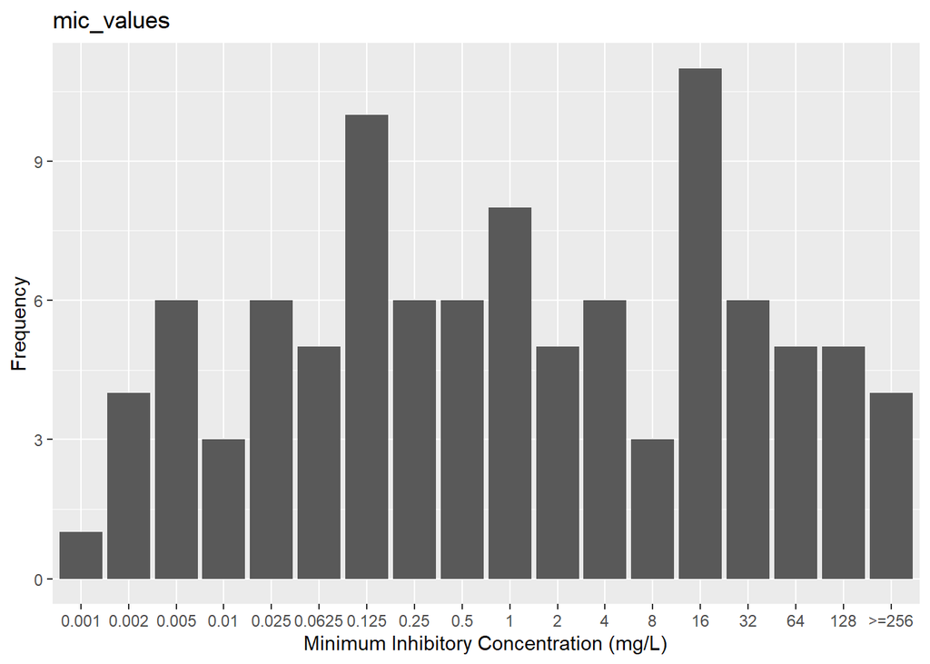

```r
#autoplot the mic values
autoplot(mic_values)
```

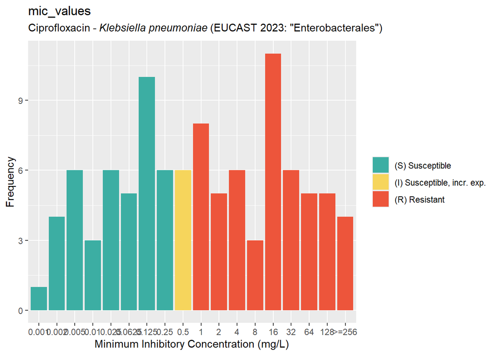

```r
autoplot(mic_values, mo = "K. pneumoniae", ab = "cipro", guideline = "EUCAST 2023")
```

The AMR R package cannot be used to generate an MIC frequency table so in the example below dplyr has been used to generate this table.

```r
#Generate random MIC values for E. coli
set.seed(123)
mic_values <- random_mic(90, mo = "Escherichia coli")

##Generate the example metadata
#Generate a vector with the antimicrobial names
antibiotic <- rep(c("Ampicillin","Gentamicin", "Tetracycline"), each = 30) #repeat each string 30 times
#Generate a vector with the animal names
animal <- rep(c("Cattle", "Pig", "Chicken"), times = 30) # repeat "Cattle", "Pig", "Chicken" 30 times
#Combine the mic values and metadata into a tibble
dat <- tibble(MIC = mic_values, Antibiotic= antibiotic, Animal = animal)
head(dat)
```

```
## # A tibble: 6 × 3
##         MIC Antibiotic Animal
##       <mic> <chr>      <chr>
## 1    16.000 Ampicillin Cattle
## 2     0.005 Ampicillin Pig
## 3     1.000 Ampicillin Chicken
## 4 >=256.000 Ampicillin Cattle
## 5     2.000 Ampicillin Pig
## 6     0.025 Ampicillin Chicken
```

```r
# Define the MIC categories
mic_breaks <- c(0, 0.25, 0.5, 1, 2, 4, 8, 16, 32, 64, Inf)
mic_labels <- c("0.25", "0.5", "1", "2", "4", "8", "16", "32", "64", "128")

# Create the frequency table
mic_table <- dat %>%
  mutate(MIC = as.numeric(MIC)) %>% #converts the MIC column to numeric class
  mutate(MIC_category = cut(MIC, breaks = mic_breaks, labels = mic_labels, right = FALSE)) %>% # cut the MIC values into bins based on the predefined breakpoints and label
  group_by(Antibiotic, Animal) %>% #group the data by antibiotic and animal
  count(MIC_category) %>% #count the number of observations for each MIC category within each group
  pivot_wider(names_from = MIC_category, values_from = n, values_fill = 0) #Reshape the data so that the MIC categories become the column names

knitr::kable(mic_table)
```

| Antibiotic | Animal | 0.25 | 1 | 2 | 32 | 128 | 4 | 64 | 0.5 | 8 | 16 |
| --- | --- | --- | --- | --- | --- | --- | --- | --- | --- | --- | --- |
| Ampicillin | Cattle | 3 | 1 | 2 | 3 | 1 | 0 | 0 | 0 | 0 | 0 |
| Ampicillin | Chicken | 5 | 1 | 2 | 0 | 0 | 1 | 1 | 0 | 0 | 0 |
| Ampicillin | Pig | 3 | 2 | 0 | 0 | 1 | 1 | 0 | 1 | 1 | 1 |
| Gentamicin | Cattle | 3 | 0 | 0 | 0 | 2 | 1 | 1 | 0 | 1 | 2 |
| Gentamicin | Chicken | 5 | 1 | 0 | 1 | 2 | 0 | 0 | 0 | 1 | 0 |
| Gentamicin | Pig | 2 | 0 | 0 | 1 | 3 | 0 | 1 | 3 | 0 | 0 |
| Tetracycline | Cattle | 1 | 0 | 2 | 3 | 0 | 1 | 1 | 0 | 2 | 0 |
| Tetracycline | Chicken | 3 | 0 | 2 | 0 | 2 | 0 | 1 | 2 | 0 | 0 |
| Tetracycline | Pig | 6 | 0 | 0 | 2 | 1 | 0 | 1 | 0 | 0 | 0 |

Write the table to a text or csv file.

```r
write.table(mic_table, file = "output/mic.txt", row.names = FALSE)
write.csv(mic_table, file = "output/mic.csv", row.names = FALSE)
```

Generate some basic statistics in a table

```r
#summarise the data using the reframe() function
dat %>%
  group_by(Antibiotic, Animal) %>%
  reframe(
    MIC_min = min(MIC),
    MIC_max = max(MIC),
    MIC50 = median(MIC),
  )
```

```
## # A tibble: 9 × 5
##   Antibiotic   Animal  MIC_min MIC_max MIC50
##   <chr>        <chr>     <dbl>   <dbl> <dbl>
## 1 Ampicillin   Cattle   0.005      256 1
## 2 Ampicillin   Chicken  0.002       32 0.312
## 3 Ampicillin   Pig      0.005      128 0.5
## 4 Gentamicin   Cattle   0.005      128 6
## 5 Gentamicin   Chicken  0.001      256 0.312
## 6 Gentamicin   Pig      0.002      256 8.12
## 7 Tetracycline Cattle   0.0625      32 4
## 8 Tetracycline Chicken  0.005      128 0.625
## 9 Tetracycline Pig      0.002      256 0.125
```

$\\$

**Determining multi-drug resistance**

Material for the following tutorial was taken from https://msberends.github.io/AMR/articles/MDR.html

The number of MDR isolates can be determined using the mdro() function. Use the example_isolates dataset to determine the number of MDR isolates. The default guideline CMI2012 based on the paper https://onlinelibrary.wiley.com/doi/full/10.1111/j.1469-0691.2011.03570.x. Use ?mrdo to check the arguments.

```r
#Generate a table with the total number of MDR isolates

mdr <- mdro(example_isolates, guideline = "CMI2012")
table(mdr)
```

```
## mdr
##                         Negative       Multi-drug-resistant (MDR)
##                             1601                              128
## Extensively drug-resistant (XDR)          Pandrug-resistant (PDR)
##                                0                                0
```

```r
example_isolates %>%
  mdro() %>% #Classify isolates as MDR using default settings
  freq() #Generate a frequency table
```

```
##
##
## **Frequency table**
##
## Class:      factor > ordered (numeric)
## Length:     2,000
## Levels:     4: Negative < Multi-drug-resistant (MDR) < Extensively drug-resistant ...
## Available:  1,729 (86.45%, NA: 271 = 13.55%)
## Unique:     2
##
##
## |   |Item                        |  Count|  Percent|  Cum. Count|  Cum. Percent|
## |:--|:---------------------------|------:|--------:|-----------:|-------------:|
## |1  |Negative                    |   1601|    92.6%|        1601|         92.6%|
## |2  |Multi-drug-resistant (MDR)  |    128|     7.4%|        1729|        100.0%|
```

```r
#Generate a table with the number of MDR isolates grouped by species
example_isolates %>%
  mutate(MDRO = mdr) %>% #create a new column called MDRO
  group_by(mo) %>%  #Group by species
  count(MDRO) %>% #Counts the number of isolates
  filter(MDRO == "Multi-drug-resistant (MDR)") #Filters for those rows that are MDR positive
```

```
## # A tibble: 13 × 3
## # Groups:   mo [13]
##    mo            MDRO                           n
##    <mo>          <ord>                      <int>
##  1 B_CTRBC       Multi-drug-resistant (MDR)     2
##  2 B_CTRBC_FRND  Multi-drug-resistant (MDR)     3
##  3 B_ENTRBC_CLOC Multi-drug-resistant (MDR)     6
##  4 B_ESCHR_COLI  Multi-drug-resistant (MDR)    68
##  5 B_HAFNI_ALVE  Multi-drug-resistant (MDR)     1
##  6 B_KLBSL_AERG  Multi-drug-resistant (MDR)     2
##  7 B_KLBSL_OXYT  Multi-drug-resistant (MDR)     2
##  8 B_KLBSL_PNMN  Multi-drug-resistant (MDR)     6
##  9 B_PROTS_MRBL  Multi-drug-resistant (MDR)     4
## 10 B_PROTS_VLGR  Multi-drug-resistant (MDR)     2
## 11 B_SERRT_MRCS  Multi-drug-resistant (MDR)    25
## 12 B_SLMNL_ENTR  Multi-drug-resistant (MDR)     3
## 13 B_STPHY_AURS  Multi-drug-resistant (MDR)     4
```

The group/class that each antimicrobial can be checked by filtering the antibiotics dataset from the AMR R package.

```r
antibiotics %>%
  select(ab, group) %>%
  filter(ab == "GEN" | ab =="CHL" | ab =="MEM" | ab =="CRO" | ab =="CIP" | ab =="FEP" | ab =="NAL" | ab =="AMP" | ab =="TCY" | ab =="SXT" | ab =="ETP" | ab =="ERY" | ab =="TGC" | ab =="QDA" | ab =="VAN" | ab =="LNZ")
```

```
## # A tibble: 16 × 2
##    ab   group
##    <ab> <chr>
##  1 AMP  Beta-lactams/penicillins
##  2 FEP  Cephalosporins (4th gen.)
##  3 CRO  Cephalosporins (3rd gen.)
##  4 CHL  Amphenicols
##  5 CIP  Quinolones
##  6 ETP  Carbapenems
##  7 ERY  Macrolides/lincosamides
##  8 GEN  Aminoglycosides
##  9 LNZ  Oxazolidinones
## 10 MEM  Carbapenems
## 11 NAL  Quinolones
## 12 QDA  Macrolides/lincosamides
## 13 TCY  Tetracyclines
## 14 TGC  Tetracyclines
## 15 SXT  Trimethoprims
## 16 VAN  Glycopeptides
```

Check how many isolates are MDR in the combined *Enterococcus*, *Salmonella*, *E. coli* dataset and filter the dataset for the isolates that are positive.

```r
mdr <- mdro(df3, guideline = "CMI2012")
df3 %>%
  mutate(MDRO = mdr) %>%
  group_by(species) %>%  #l
  count(MDRO)
```

```
## # A tibble: 5 × 3
## # Groups:   species [3]
##   species          MDRO                           n
##   <chr>            <ord>                      <int>
## 1 Enterococcus sp. <NA>                         239
## 2 Escherichia coli Multi-drug-resistant (MDR)    21
## 3 Escherichia coli <NA>                         105
## 4 Salmonella sp.   Multi-drug-resistant (MDR)     3
## 5 Salmonella sp.   <NA>                          25
```

```r
df3_mdr <- df3 %>%
  mutate(MDRO = mdr)

# Filter for MDR isolates
df3_mdr %>% filter(MDRO == "Multi-drug-resistant (MDR)")
```

```
## # A tibble: 24 × 46
##    species          meat_shop    stratification date_collection sample_type
##    <chr>            <chr>        <chr>          <date>          <chr>
##  1 Escherichia coli Wangyal MS   STII-07        2021-08-23      Broiler
##  2 Escherichia coli Dhimali MS   STI-15         2021-07-09      Broiler
##  3 Escherichia coli DB MS        STII-11        2021-09-21      Broiler
##  4 Escherichia coli Sipsoo MS    STII-16        2021-05-10      Broiler
##  5 Escherichia coli IB MS        STI-01         2021-05-10      Broiler
##  6 Escherichia coli Tek Maya MS  STII-19        2021-07-10      Broiler
##  7 Escherichia coli Motithang MS STII-18        2021-07-10      Broiler
##  8 Escherichia coli Good Meal MS STIII-03       2021-05-10      Broiler
##  9 Escherichia coli Chang MS     STI-08         2021-04-10      Broiler
## 10 Escherichia coli Olakha MS    STI-12         2021-04-10      Broiler
## # ℹ 14 more rows
## # ℹ 41 more variables: sample_collection <chr>, sample_weight_Kg <dbl>,
## #   sample_source <chr>, farm_category <chr>, slaughter <chr>,
## #   transportation <chr>, transport_medium <chr>,
## #   transport_with_other_meat <chr>, GEN <sir>, CHL <sir>, MEM <sir>,
## #   CRO <sir>, CIP <sir>, FEP <sir>, NAL <sir>, AMP <sir>, TCY <sir>,
## #   SXT <sir>, ETP <sir>, ERY <sir>, TGC <sir>, QDA <sir>, VAN <sir>, …
```

$\\$

### Principal Component analysis

PCA analysis can be used for grouping and visualising datasets. Note when using the AMR R package for PCA analysis 30 observations are required for each grouped variable.

Use the example_isolates dataset from the AMR package to generate a PCA plot where the SIR data for the antimicrobials AMC, CXM, CTX, CAZ, GEN, TOB, TMP, SXT are used as the features and the data is grouped by order and genus.

```r
set.seed(123)
resistance_data <- example_isolates %>%
  group_by(
    order = mo_order(mo), # group on anything, like order
    genus = mo_genus(mo)) %>%
  summarise_if(is.sir, resistance) %>% # then get resistance of all drugs
  select(
    order, genus, AMC, CXM, CTX,
    CAZ, GEN, TOB, TMP, SXT
  ) # and select only relevant columns
pca_result <- pca(resistance_data)
```

```
## ℹ Columns selected for PCA: "AMC", "CAZ", "CTX", "CXM", "GEN", "SXT",
##   "TMP", and "TOB". Total observations available: 7.
```

```r
summary(pca_result)
```

```
## Groups (n=4, named as 'order'):
## [1] "Caryophanales"    "Enterobacterales" "Lactobacillales"  "Pseudomonadales"
```

```
## Importance of components:
##                           PC1    PC2    PC3     PC4     PC5     PC6       PC7
## Standard deviation     2.1539 1.6807 0.6138 0.33879 0.20808 0.03140 5.674e-17
## Proportion of Variance 0.5799 0.3531 0.0471 0.01435 0.00541 0.00012 0.000e+00
## Cumulative Proportion  0.5799 0.9330 0.9801 0.99446 0.99988 1.00000 1.000e+00
```

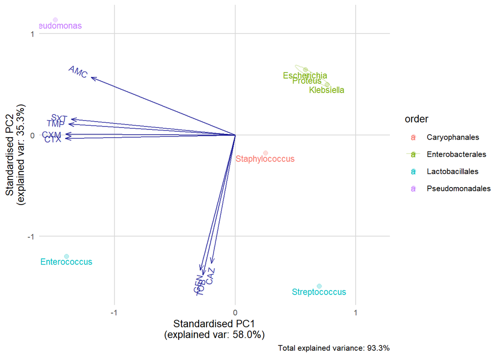

```r
ggplot_pca(pca_result) # plot the results
```

Use the surveillance data or your own data to generate a PCA plot. Try grouping on one of the sample metadata variables.

```r
##Using the Surveillance data
##This isn't a very good example.

pca_df <- df3 %>%
  filter(species == "Enterococcus sp.") %>%
  group_by(sample_collection) %>%
  summarise_if(is.sir, resistance) %>%
  select(sample_collection, CHL, AMP, TCY, ERY, VAN)# then get resistance of all drugs
  # and select only relevant columns

pca_result <- pca(pca_df)
```

```
## ℹ Columns selected for PCA: "AMP", "CHL", "ERY", "TCY", and "VAN". Total
##   observations available: 2.
```

```r
summary(pca_result)
```

```
## Groups (n=2, named as 'sample_collection'):
## [1] "Display table" "Fridge"
```

```
## Importance of components:
##                          PC1       PC2
## Standard deviation     2.236 6.426e-16
## Proportion of Variance 1.000 0.000e+00
## Cumulative Proportion  1.000 1.000e+00
```

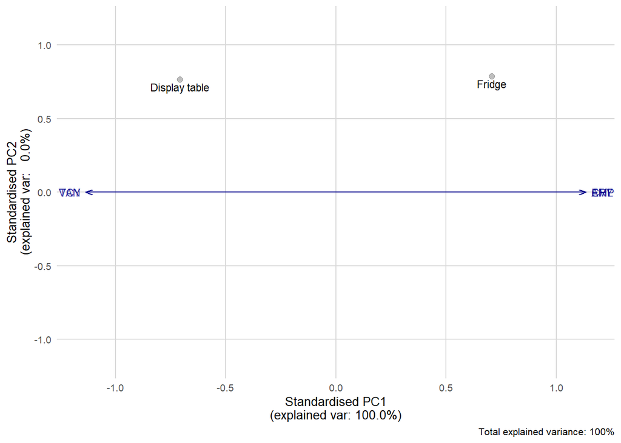

```r
ggplot_pca(pca_result)
```

Note there are other methods in R for generating PCoA plots that probably have more flexibility. $\\$

## Day 4 - Plotting

If the merged ecoli, enterococci and salmonella data set is not still in your environment. Reload the data sets, tidy them and join them together by rerunning the script generated from day 1 (to generate the data frame assigned to df3).

ggplots are made up of geoms and aesthetics. The geoms are the way in which the data is plotted e.g. points, lines, bars. The aesthetics (aes) are the way in which data is mapped to things like the size shape and colour.

The main structure for generating a ggplot is:

`ggplot(data = <dataframe> +`

`geom<name>(mapping = aes(x = <x_variable>, y = <y_variable>, color = <variable_for_color>)) + labs(x = <x_axis_label>, y = <y_axis_label>))`

See the basics of ggplot from the arranging and visualising coursera course or [ggplot2 website](https://ggplot2.tidyverse.org/) for more about ggplots.

$\\$

**Some basic examples of plots**

Here are some basic examples of how to construct scatterplots.The color or shape arguments can be used to change the appearance of the points. The facet_wrap function is used to wrap multiple plots together. The geom_smooth function adds in an overall trend line as well as the 95% confidence intervals for that line, which are represented by the gray zone.

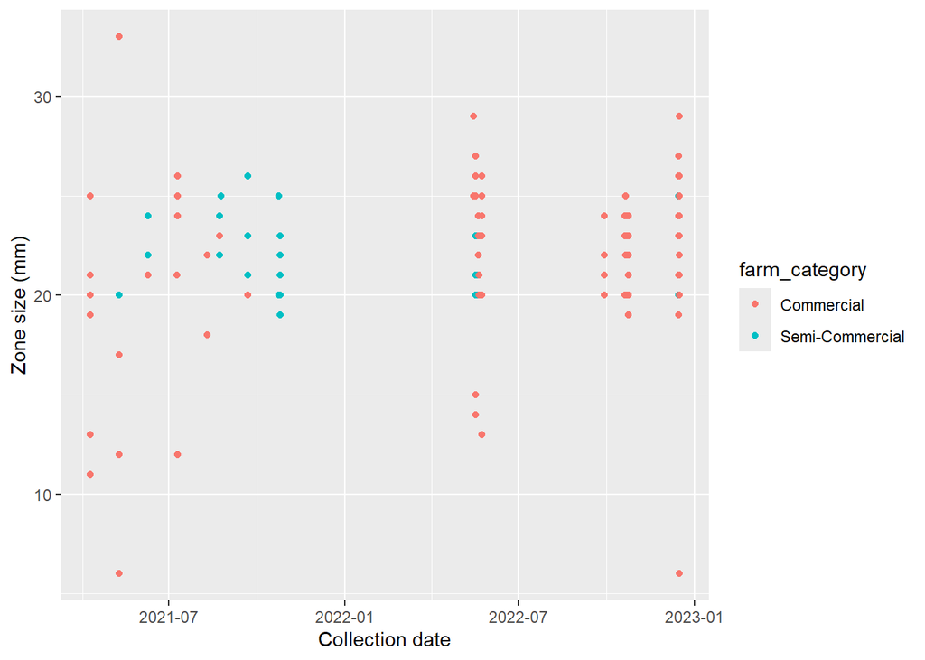

```r
#Basic scatter plots
ggplot(data = ecoli3) +
  geom_point(mapping = aes(x = date_collection, y = CHL_disk, color = farm_category)) +
  labs(x = "Collection date", y = "Zone size (mm)" )
```

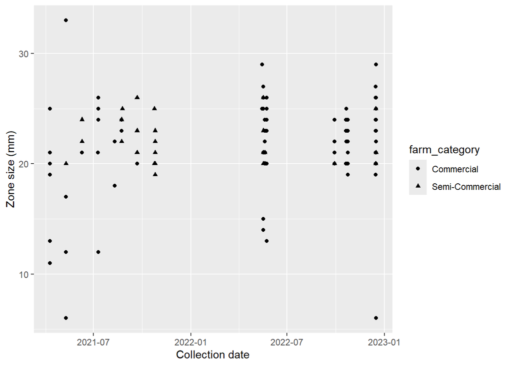

```r
ggplot(data = ecoli3) +
  geom_point(mapping = aes(x = date_collection, y = CHL_disk, shape = farm_category)) +
  labs(x = "Collection date", y = "Zone size (mm)" )
```

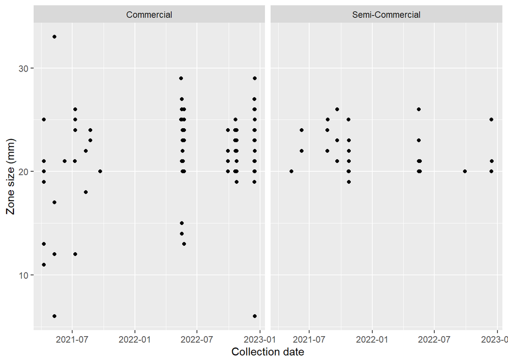

```r
ggplot(data = ecoli3) +
  geom_point(mapping = aes(x = date_collection, y = CHL_disk)) +
  facet_wrap(.~farm_category) +
  labs(x = "Collection date", y = "Zone size (mm)" )
```

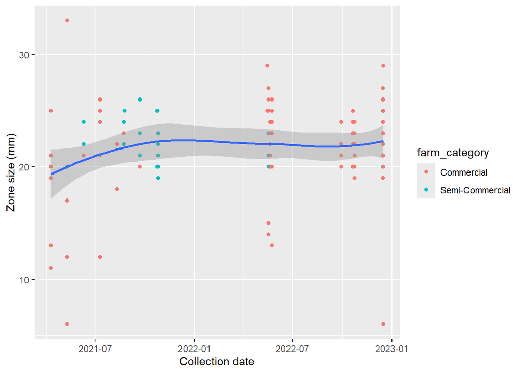

```r
ggplot(data = ecoli3) +
  geom_point(mapping = aes(x = date_collection, y = CHL_disk, color = farm_category)) +
  geom_smooth(mapping = aes(x = date_collection, y = CHL_disk)) +
  labs(x = "Collection date", y = "Zone size (mm)" )
```

geom_line() is used to generate a line graph.

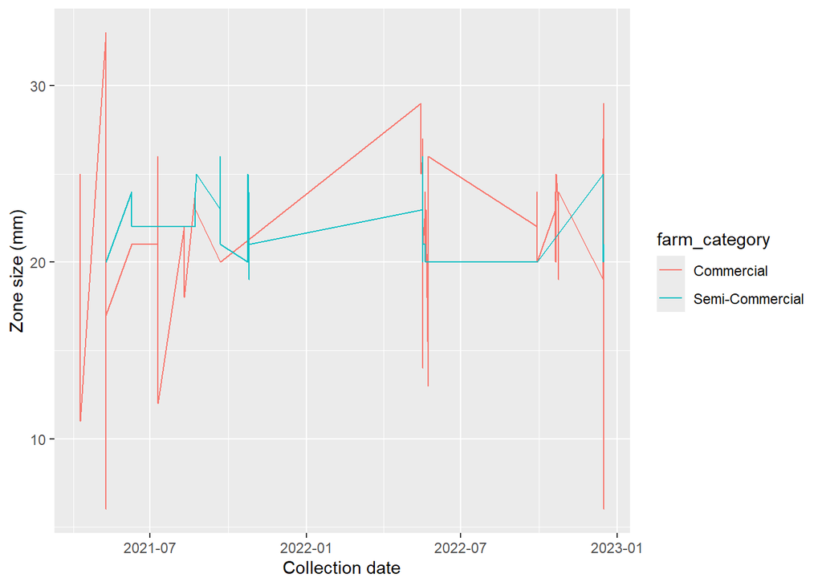

```r
ggplot(data = ecoli3) +
  geom_line(mapping = aes(x = date_collection, y = CHL_disk, color = farm_category)) +
  labs(x = "Collection date", y = "Zone size (mm)" )
```

geom_histogram() is used to generate a histogram

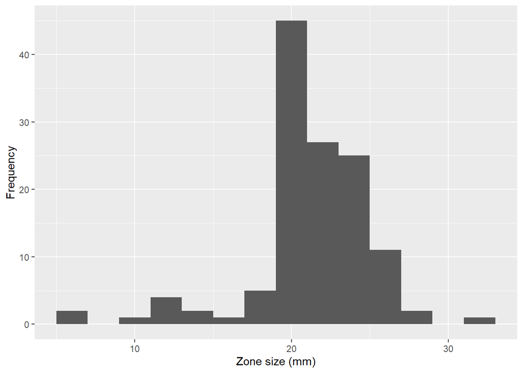

```r
ggplot(data = ecoli3) +
  geom_histogram(mapping = aes(x = CHL_disk),
                 binwidth = 2) +
  labs(x = "Zone size (mm)", y = "Frequency" )
```

Use geom_bar() to generate a bar plot of sample collection point versus E.coli SIR count for the antimicrobial CHL using the surveillance data.

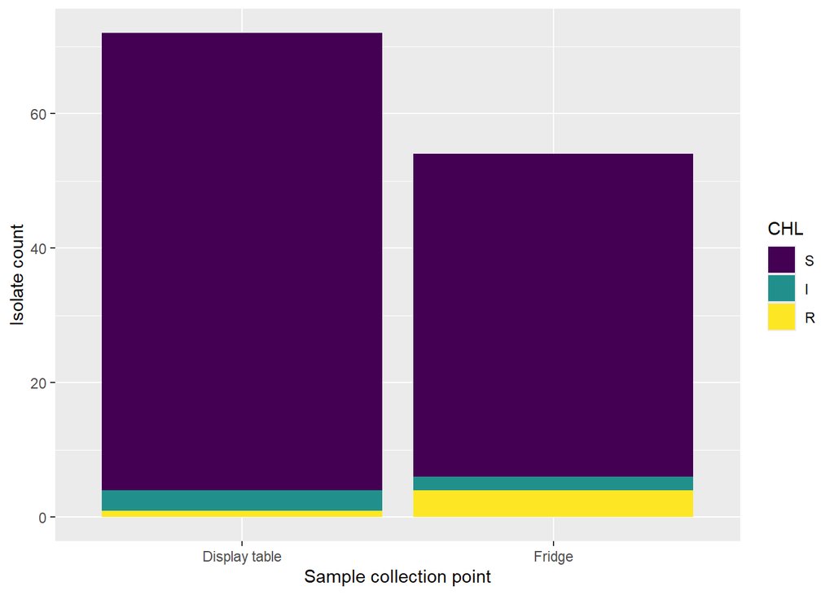

```r
#filter the combined
df4 <- df3 %>%
  filter(species == "Escherichia coli") %>%
  select(sample_collection, CHL, CHL_disk)

#Barplot with counts
ggplot(data = df4) +
  geom_bar(mapping = aes(x = sample_collection, fill = CHL)) +
  labs(x = "Sample collection point", y = "Isolate count" )
```

Flip the bar plot

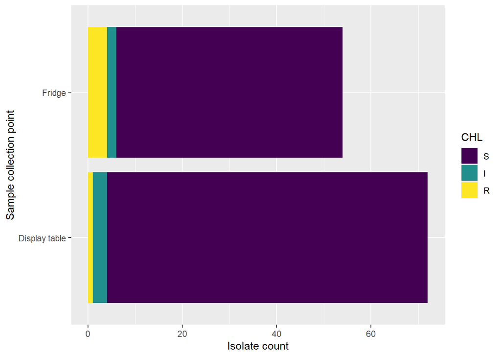

```r
ggplot(data = df4) +
  geom_bar(mapping = aes(x = sample_collection, fill = CHL)) +
  coord_flip() +
  labs(y = "Isolate count", x = "Sample collection point")
```